# 1-Problem:

in our project we chose the dataset of the restaurants in Zomato which is an Indian multinational restaurant aggregator and food delivery company. This dataset contains information about various restaurants listed on the platform, including their location, cuisine type, ratings, and other essential attributes.we will study and analyze the restaurants data that will help us identify the preferred cost range and the most likable restaurant type and cuisines type that leads into high ratings to help people who are interested in putting their restaurants on the platform by predicting the ratings of new restaurants on the platform.

# 2-Data Mining Task:

We want to solve this problem by classification data mining task, to predict the highest ratings based on restaurant type, average cost of two people, and the cuisine’s type, by choosing rating as class label.

# 3- Data:

We choose this data from Kaggle website(https://www.kaggle.com/datasets/abhijitdahatonde/zomato-restaurants-dataset) This dataset provides us with information about different type of restaurant and there ratings in food application called Zomato, it consists the following attributes:

Number of attributes:12

[output not shown]

## Missing value

```r
zomato <- read.csv("zomato.csv")
```

```r
summary(zomato)
```

```
      ï..         Unnamed..0               restaurant.name
 Min.   :   0   Min.   :   0   '@ Biryani Central  :   1
 1st Qu.:1776   1st Qu.:1776   '@ The Bbq          :   1
 Median :3552   Median :3552   '@99                :   1
 Mean   :3552   Mean   :3552   '@Italy             :   1
 3rd Qu.:5328   3rd Qu.:5328   '@North Parontha Hut:   1
 Max.   :7104   Max.   :7104   #FeelTheROLL        :   1
                               (Other)             :7099
           restaurant.type      rate        numofratings        avgCost
 Quick Bites       :2840   Min.   :1.800   Min.   :    1.0   Min.   :  40.0
 Casual Dining     :1634   1st Qu.:3.200   1st Qu.:   16.0   1st Qu.: 300.0
 Cafe              : 403   Median :3.500   Median :   40.0   Median : 400.0
 Delivery          : 358   Mean   :3.514   Mean   :  188.9   Mean   : 540.3
 Takeaway, Delivery: 289   3rd Qu.:3.800   3rd Qu.:  128.0   3rd Qu.: 600.0
 Dessert Parlor    : 217   Max.   :4.900   Max.   :16345.0   Max.   :6000.0
 (Other)           :1364   NA's   :68                        NA's   :57
 online_order tablebooking                              cuisinestype
 No :3378     No :6361     North Indian, Chinese              : 421
 Yes:3727     Yes: 744     North Indian                       : 420
                           South Indian                       : 348
                           Fast Food                          : 140
                           South Indian, North Indian, Chinese: 128
                           Biryani                            : 122
                           (Other)                            :5526
                             area               localaddress
 Byresandra,Tavarekere,Madiwala: 798   Whitefield     : 459
 Bannerghatta Road             : 552   BTM            : 458
 Brookefield                   : 477   Electronic City: 404
 Brigade Road                  : 464   Marathahalli   : 381
 Indiranagar                   : 455   HSR            : 378
 Electronic City               : 403   Indiranagar    : 292
 (Other)                       :3956   (Other)        :4733
```

```r
sum(is.na(zomato))
```

125

```r
summary(zomato$rate)
```

```
   Min. 1st Qu.  Median    Mean 3rd Qu.    Max.    NA's
  1.800   3.200   3.500   3.514   3.800   4.900      68
```

```r
summary(zomato$rate)
```

```
   Min. 1st Qu.  Median    Mean 3rd Qu.    Max.    NA's
  1.800   3.200   3.500   3.514   3.800   4.900      68
```

```r
summary(zomato$avgCost)
```

```
   Min. 1st Qu.  Median    Mean 3rd Qu.    Max.    NA's
   40.0   300.0   400.0   540.3   600.0  6000.0      57
```

## Boxplot

```r
boxplot.stats(zomato$rate)$out
```

1. 1.8

2. 4.9

3. 2.1

4. 4.7

5. 4.8

6. 2

7. 4.7

8. 2.3

9. 4.7

10. 4.9

11. 2.3

12. 4.7

13. 2.1

14. 4.7

15. 4.7

16. 2

17. 4.7

18. 2.1

19. 2.2

20. 2.1

21. 4.7

22. 2.3

23. 2.1

24. 4.8

25. 4.8

26. 2.3

27. 4.9

28. 4.7

29. 2.2

30. 2.2

31. 4.7

32. 4.7

33. 4.7

34. 4.8

35. 4.7

36. 2.3

37. 2.3

38. 2.3

39. 4.7

```r
boxplot.stats(zomato$avgCost)$out
```

3. 1400

4. 2500

5. 1400

6. 3000

7. 3000

8. 1100

9. 1100

10. 1600

11. 1400

12. 1300

13. 1100

14. 1400

15. 1300

16. 1400

17. 1800

18. 4000

19. 2000

20. 2000

21. 1200

22. 2500

23. 1900

24. 3000

25. 1500

26. 2000

27. 1500

28. 3000

29. 2000

30. 2000

31. 1400

32. 1800

33. 2000

34. 1500

35. 1800

36. 1200

37. 1100

38. 3400

39. 1100

40. 1200

41. 1500

42. 1100

43. 3700

44. 1300

45. 1100

46. 3000

47. 1500

48. 1700

49. 1100

50. 1700

51. 1500

52. 2500

53. 1300

54. 1200

55. 1600

56. 1300

57. 1500

58. 2000

59. 1400

60. 1100

61. 2400

62. 1500

63. 1500

64. 2200

65. 2500

66. 1400

67. 1500

68. 1800

69. 1500

70. 1600

71. 1600

72. 1100

73. 1200

74. 1500

75. 1600

76. 2400

77. 1800

78. 1400

79. 1200

80. 1400

81. 1200

82. 1300

83. 2100

84. 1200

85. 1500

86. 2500

87. 3200

88. 2000

89. 1500

90. 1500

91. 1200

92. 1500

93. 1500

94. 1100

95. 1800

96. 1300

97. 1200

98. 1800

99. 1400

100. 1200

101. 1200

102. 1400

103. 1400

104. 1500

105. 1400

106. 1600

107. 1500

108. 1100

109. 1300

110. 1800

111. 1600

112. 1200

113. 1300

114. 1300

115. 1500

116. 1500

117. 1200

118. 1500

119. 1100

120. 1500

121. 1700

122. 1600

123. 1700

124. 1700

125. 1700

126. 1200

127. 1100

128. 1600

129. 1300

130. 2500

131. 1500

132. 2000

133. 2200

134. 3000

135. 1200

136. 2800

137. 1100

138. 1400

139. 1100

140. 1200

141. 1200

142. 1400

143. 1400

144. 1200

145. 1300

146. 1100

147. 2500

148. 1500

149. 1400

150. 1200

151. 2500

152. 1500

153. 1600

154. 1100

155. 1200

156. 1500

157. 1500

158. 1100

159. 1400

160. 1500

161. 1500

162. 1400

163. 3500

164. 1900

165. 2200

166. 1100

167. 1500

168. 1500

169. 1200

170. 1200

171. 1400

172. 1100

173. 1200

174. 2500

175. 1400

176. 4000

177. 1500

178. 1300

179. 1100

180. 1100

181. 1800

182. 1300

183. 1500

184. 2000

185. 1300

186. 1500

187. 2500

188. 4000

189. 2200

190. 1100

191. 1500

192. 1100

193. 4000

194. 1100

195. 1400

196. 1200

197. 1300

198. 1900

199. 1600

200. 1200

201. 1250

202. 1250

203. 1100

204. 1500

205. 1500

206. 1200

207. 1500

208. 2000

209. 2500

210. 1500

211. 1600

212. 1200

213. 1200

214. 1200

215. 1500

216. 2600

217. 1900

218. 1200

219. 1400

220. 1500

221. 1800

222. 1500

223. 1800

224. 1200

225. 1200

226. 2000

227. 1500

228. 1600

229. 1400

230. 1200

231. 2000

232. 1900

233. 1400

234. 1400

235. 1200

236. 1100

237. 4000

238. 1500

239. 1200

240. 1200

241. 1100

242. 1100

243. 1200

244. 1200

245. 1500

246. 2500

247. 2000

248. 1400

249. 1200

250. 1200

251. 1250

252. 1800

253. 2600

254. 1400

255. 1300

256. 1100

257. 1300

258. 3000

259. 3000

260. 2800

261. 2500

262. 2500

263. 3000

264. 1500

265. 1250

266. 1400

267. 2700

268. 1600

269. 2500

270. 2000

271. 1600

272. 1200

273. 1300

274. 4000

275. 2000

276. 1300

277. 1800

278. 1650

279. 1100

280. 1700

281. 1500

282. 1100

283. 2200

284. 1400

285. 3500

286. 2000

287. 1500

288. 1800

289. 1200

290. 3000

291. 3000

292. 3500

293. 1200

294. 1200

295. 1500

296. 3000

297. 2000

298. 1300

299. 1500

300. 1200

301. 1500

302. 1200

303. 1200

304. 1100

305. 2000

306. 4100

307. 1500

308. 1300

309. 2000

310. 1600

311. 2000

312. 6000

313. 3000

314. 2000

315. 1500

316. 3000

317. 2200

318. 2400

319. 1500

320. 1200

321. 2100

322. 1500

323. 3000

324. 1300

325. 1600

326. 1200

327. 1200

328. 2000

329. 2500

330. 1400

331. 1200

332. 1200

333. 1700

334. 4500

335. 1600

336. 1100

337. 1200

338. 1200

339. 1500

340. 1800

341. 4000

342. 1700

343. 1800

344. 1500

345. 1100

346. 2700

347. 3000

348. 1500

349. 1200

350. 3000

351. 1100

352. 3000

353. 2000

354. 1400

355. 1700

356. 2000

357. 1400

358. 3000

359. 1600

360. 1500

361. 1400

362. 1700

363. 1800

364. 2000

365. 2500

366. 1200

367. 1100

368. 1200

369. 1200

370. 2000

371. 1500

372. 1400

373. 2000

374. 1400

375. 1800

376. 1900

377. 1500

378. 2000

379. 2000

380. 1200

381. 1200

382. 2200

383. 1800

384. 1500

385. 1300

386. 1200

387. 1600

388. 1200

389. 1400

390. 1700

391. 1900

392. 1800

393. 1100

394. 3000

395. 1400

396. 1700

397. 1450

398. 1200

399. 1200

400. 1300

401. 1200

402. 1200

403. 1500

404. 1100

405. 1100

406. 1100

407. 1100

408. 1200

409. 1100

410. 1600

411. 1100

412. 1200

413. 3000

414. 1500

415. 2300

416. 1800

417. 2000

418. 1600

419. 1700

420. 1400

421. 1300

422. 1400

423. 1200

424. 1400

425. 1200

426. 1200

427. 1200

428. 1700

429. 1500

430. 1800

431. 1400

432. 3000

433. 4000

434. 1900

435. 1300

436. 1200

437. 5000

438. 1300

439. 1100

440. 2500

441. 1400

442. 1500

443. 1500

444. 1200

445. 2000

446. 1600

447. 1200

448. 1200

449. 1500

450. 1500

451. 1200

452. 1200

453. 1100

454. 1100

455. 1200

456. 1200

457. 1200

458. 1500

459. 1500

460. 1400

461. 2000

462. 1500

463. 1500

464. 1500

465. 1500

466. 3000

467. 1800

468. 1200

469. 1300

470. 1500

471. 1400

472. 1400

473. 1100

474. 1100

475. 1500

476. 1500

477. 1500

478. 2500

479. 2000

480. 1200

481. 1500

482. 1500

483. 2500

484. 1500

485. 1600

486. 1300

487. 1100

488. 1500

489. 1200

490. 2000

491. 2000

492. 1200

493. 1700

494. 1500

495. 1200

496. 1200

497. 3000

498. 2500

499. 1500

500. 3000

501. 1100

502. 1500

503. 1200

504. 1200

505. 1300

506. 2100

507. 2200

508. 2500

509. 1300

510. 2100

511. 1100

512. 1200

513. 2000

514. 1800

515. 2000

516. 1600

517. 3000

518. 1200

519. 1700

520. 1200

521. 1700

522. 1300

523. 1500

524. 1400

525. 1100

526. 2000

527. 2000

528. 1700

529. 1500

530. 1400

531. 1500

532. 1800

533. 1200

534. 1200

535. 1200

536. 1100

537. 1200

538. 2000

539. 1100

540. 1500

541. 1700

542. 1700

543. 1400

544. 1200

545. 1400

546. 1200

547. 1500

548. 1300

549. 1100

550. 1300

551. 1200

552. 2200

553. 1700

554. 1400

555. 1100

556. 1700

557. 1500

558. 3500

559. 1200

560. 2200

561. 2000

562. 2000

563. 1400

564. 1500

565. 1300

566. 1350

567. 2000

568. 1200

569. 3400

570. 1500

571. 1400

572. 1400

573. 1300

574. 1600

575. 1500

576. 2500

577. 1200

578. 1200

579. 1500

580. 2400

581. 1300

582. 1200

583. 1100

584. 1300

585. 1500

586. 2000

587. 3000

588. 1200

589. 2500

590. 1350

591. 2500

592. 1400

593. 2000

594. 2100

595. 2500

596. 1400

597. 1800

598. 1500

599. 2800

600. 1600

601. 1200

602. 1200

603. 1300

604. 1300

605. 1500

606. 2500

607. 2000

608. 1300

609. 2000

610. 2800

611. 1500

612. 1400

613. 1100

614. 1300

615. 1400

616. 1500

617. 1500

618. 1500

619. 1500

620. 1200

621. 1500

622. 1200

623. 1200

624. 2000

625. 1800

626. 2000

627. 1200

628. 1200

629. 1400

630. 1400

631. 1800

632. 1200

633. 1500

634. 1100

635. 1700

636. 2000

637. 1200

638. 1500

639. 1800

640. 1300

641. 2000

642. 1200

643. 1100

644. 1500

645. 1200

646. 3000

647. 1500

648. 2500

649. 1400

650. 2000

651. 1400

652. 2400

653. 2300

654. 2800

655. 2000

656. 1200

657. 1200

658. 1500

659. 3500

660. 1500

661. 1800

```r
boxplot.stats(zomato$numofratings)$out
```

3. 353

4. 1731

5. 1509

6. 620

7. 595

8. 419

9. 932

10. 344

11. 1234

12. 556

13. 1149

14. 662

15. 399

16. 737

17. 1763

18. 478

19. 531

20. 458

21. 2871

22. 544

23. 888

24. 574

25. 1502

26. 405

27. 377

28. 783

29. 867

30. 336

31. 1413

32. 567

33. 370

34. 561

35. 682

36. 346

37. 446

38. 704

39. 387

40. 314

41. 821

42. 568

43. 435

44. 1428

45. 317

46. 739

47. 434

48. 461

49. 730

50. 841

51. 474

52. 339

53. 8375

54. 533

55. 449

56. 861

57. 2178

58. 1229

59. 577

60. 506

61. 610

62. 734

63. 429

64. 504

65. 634

66. 479

67. 903

68. 527

69. 1383

70. 532

71. 1014

72. 477

73. 612

74. 2212

75. 764

76. 474

77. 1003

78. 1303

79. 1316

80. 592

81. 2445

82. 842

83. 4650

84. 496

85. 345

86. 869

87. 419

88. 367

89. 415

90. 456

91. 391

92. 541

93. 521

94. 858

95. 1899

96. 859

97. 426

98. 854

99. 418

100. 779

101. 1550

102. 662

103. 320

104. 746

105. 6865

106. 555

107. 9272

108. 678

109. 347

110. 317

111. 301

112. 751

113. 298

114. 627

115. 1071

116. 618

117. 1845

118. 400

119. 318

120. 1214

121. 733

122. 935

123. 514

124. 505

125. 401

126. 330

127. 1721

128. 866

129. 717

130. 2355

131. 555

132. 2616

133. 1636

134. 601

135. 700

136. 973

137. 1187

138. 5894

139. 970

140. 2329

141. 4321

142. 1633

143. 387

144. 1142

145. 3870

146. 879

147. 356

148. 351

149. 3125

150. 345

151. 2448

152. 1594

153. 605

154. 782

155. 1345

156. 16345

157. 1989

158. 1233

159. 402

160. 688

161. 721

162. 721

163. 500

164. 559

165. 388

166. 869

167. 496

168. 351

169. 1048

170. 1654

171. 1059

172. 513

173. 563

174. 583

175. 500

176. 373

177. 577

178. 431

179. 424

180. 559

181. 719

182. 540

183. 1423

184. 980

185. 600

186. 341

187. 842

188. 343

189. 405

190. 420

191. 444

192. 825

193. 1275

194. 997

195. 342

196. 2233

197. 960

198. 353

199. 395

200. 319

201. 4955

202. 378

203. 307

204. 455

205. 2658

206. 445

207. 358

208. 746

209. 557

210. 308

211. 7544

212. 1403

213. 2339

214. 1269

215. 331

216. 589

217. 417

218. 364

219. 466

220. 3998

221. 820

222. 2589

223. 583

224. 4408

225. 678

226. 306

227. 507

228. 739

229. 334

230. 325

231. 384

232. 475

233. 409

234. 2487

235. 505

236. 909

237. 3423

238. 498

239. 361

240. 344

241. 1414

242. 1287

243. 463

244. 1800

245. 372

246. 798

247. 2316

248. 758

249. 1341

250. 652

251. 297

252. 371

253. 2651

254. 1445

255. 344

256. 327

257. 3826

258. 497

259. 2240

260. 370

261. 1531

262. 3126

263. 3197

264. 612

265. 391

266. 608

267. 669

268. 2192

269. 330

270. 731

271. 1095

272. 505

273. 1077

274. 1563

275. 553

276. 1065

277. 2392

278. 455

279. 1272

280. 2039

281. 383

282. 950

283. 523

284. 6348

285. 597

286. 808

287. 751

288. 454

289. 648

290. 418

291. 302

292. 7154

293. 3061

294. 471

295. 1386

296. 308

297. 506

298. 319

299. 334

300. 1146

301. 366

302. 379

303. 702

304. 551

305. 407

306. 395

307. 414

308. 1249

309. 300

310. 836

311. 707

312. 794

313. 777

314. 384

315. 469

316. 371

317. 409

318. 1824

319. 3447

320. 732

321. 424

322. 1187

323. 2838

324. 715

325. 564

326. 321

327. 637

328. 332

329. 827

330. 815

331. 1875

332. 600

333. 330

334. 868

335. 951

336. 1189

337. 1187

338. 330

339. 2781

340. 380

341. 1413

342. 1796

343. 2151

344. 507

345. 633

346. 5262

347. 666

348. 1365

349. 469

350. 368

351. 344

352. 880

353. 1116

354. 1580

355. 4767

356. 308

357. 7193

358. 1703

359. 332

360. 787

361. 485

362. 328

363. 341

364. 678

365. 3573

366. 540

367. 460

368. 320

369. 820

370. 311

371. 633

372. 1463

373. 357

374. 374

375. 1369

376. 374

377. 617

378. 608

379. 1837

380. 767

381. 535

382. 1218

383. 674

384. 485

385. 2368

386. 399

387. 864

388. 323

389. 310

390. 327

391. 429

392. 675

393. 775

394. 3421

395. 519

396. 977

397. 1042

398. 2807

399. 815

400. 1827

401. 315

402. 476

403. 2111

404. 528

405. 327

406. 451

407. 334

408. 570

409. 418

410. 543

411. 889

412. 334

413. 1555

414. 674

415. 363

416. 858

417. 885

418. 370

419. 355

420. 630

421. 305

422. 988

423. 356

424. 528

425. 306

426. 570

427. 306

428. 488

429. 800

430. 398

431. 412

432. 379

433. 571

434. 1697

435. 4650

436. 571

437. 3605

438. 431

439. 1901

440. 396

441. 330

442. 353

443. 326

444. 1166

445. 869

446. 309

447. 570

448. 1381

449. 497

450. 327

451. 404

452. 1095

453. 318

454. 1235

455. 580

456. 593

457. 328

458. 535

459. 687

460. 1218

461. 334

462. 428

463. 464

464. 786

465. 405

466. 346

467. 3586

468. 1024

469. 356

470. 1717

471. 323

472. 777

473. 409

474. 821

475. 789

476. 907

477. 668

478. 860

479. 1004

480. 881

481. 1778

482. 337

483. 1541

484. 2558

485. 406

486. 485

487. 560

488. 1320

489. 783

490. 666

491. 391

492. 546

493. 551

494. 430

495. 309

496. 337

497. 397

498. 340

499. 391

500. 858

501. 560

502. 323

503. 375

504. 1745

505. 3334

506. 426

507. 785

508. 347

509. 449

510. 455

511. 599

512. 2266

513. 468

514. 1240

515. 320

516. 914

517. 335

518. 684

519. 625

520. 3848

521. 547

522. 551

523. 380

524. 383

525. 382

526. 2709

527. 697

528. 727

529. 504

530. 1286

531. 1233

532. 2031

533. 888

534. 465

535. 426

536. 339

537. 337

538. 1213

539. 484

540. 970

541. 920

542. 361

543. 1282

544. 535

545. 308

546. 1056

547. 907

548. 349

549. 522

550. 368

551. 600

552. 386

553. 782

554. 393

555. 376

556. 376

557. 471

558. 2096

559. 1070

560. 336

561. 411

562. 671

563. 300

564. 1156

565. 439

566. 1105

567. 418

568. 511

569. 2194

570. 539

571. 2729

572. 2062

573. 1236

574. 324

575. 413

576. 355

577. 463

578. 1496

579. 1117

580. 837

581. 900

582. 1388

583. 756

584. 1075

585. 490

586. 929

587. 1644

588. 300

589. 297

590. 332

591. 601

592. 765

593. 370

594. 372

595. 847

596. 481

597. 548

598. 1089

599. 324

600. 1133

601. 868

602. 486

603. 2921

604. 532

605. 784

606. 1021

607. 334

608. 434

609. 521

610. 552

611. 650

612. 356

613. 823

614. 2039

615. 456

616. 322

617. 407

618. 7854

619. 956

620. 673

621. 532

622. 444

623. 650

624. 323

625. 416

626. 353

627. 378

628. 431

629. 669

630. 1025

631. 457

632. 327

633. 297

634. 385

635. 307

636. 465

637. 741

638. 314

639. 378

640. 434

641. 725

642. 313

643. 402

644. 763

645. 804

646. 552

647. 1980

648. 501

649. 385

650. 550

651. 624

652. 979

653. 487

654. 484

655. 796

656. 1877

657. 750

658. 468

659. 1047

660. 413

661. 307

662. 435

663. 774

664. 3056

665. 463

666. 1499

667. 1279

668. 582

669. 1372

670. 457

671. 667

672. 813

673. 518

674. 2073

675. 677

676. 442

677. 533

678. 2044

679. 484

680. 918

681. 432

682. 1028

683. 421

684. 331

685. 750

686. 1193

687. 759

688. 353

689. 441

690. 467

691. 827

692. 538

693. 514

694. 426

695. 349

696. 325

697. 380

698. 1101

699. 1105

700. 343

701. 345

702. 392

703. 457

704. 405

705. 391

706. 1867

707. 2229

708. 2486

709. 1313

710. 356

711. 840

712. 371

713. 331

714. 340

715. 597

716. 492

717. 430

718. 3003

719. 1099

720. 376

721. 514

722. 1554

723. 513

724. 1932

725. 681

726. 417

727. 566

728. 537

729. 1418

730. 764

731. 3116

732. 707

733. 364

734. 379

735. 953

736. 504

737. 1205

738. 2490

739. 3651

740. 377

741. 524

742. 956

743. 314

744. 433

745. 358

746. 1033

747. 382

748. 1230

749. 787

750. 325

751. 755

752. 861

753. 351

754. 558

755. 343

756. 336

757. 471

758. 592

759. 687

760. 751

761. 2697

762. 2315

763. 2022

764. 3458

765. 499

766. 775

767. 589

768. 591

769. 1647

770. 402

771. 651

772. 521

773. 946

774. 611

775. 1360

776. 1788

777. 322

778. 324

779. 336

780. 331

781. 6745

782. 619

783. 1141

784. 656

785. 413

786. 522

787. 901

788. 1337

789. 367

790. 4575

791. 1380

792. 785

793. 473

794. 634

795. 673

796. 523

797. 552

798. 2283

799. 524

800. 520

801. 426

802. 10413

803. 4187

804. 4947

805. 311

806. 1028

807. 512

808. 473

809. 383

810. 442

811. 3077

812. 328

813. 399

814. 1739

815. 3760

816. 4108

817. 1143

818. 797

819. 1060

820. 854

821. 320

822. 7113

823. 2418

824. 793

825. 358

826. 773

827. 888

828. 430

829. 1196

830. 1408

831. 3953

832. 542

833. 612

834. 569

835. 2923

836. 2270

837. 672

838. 2745

839. 319

840. 402

841. 1573

842. 563

843. 1724

844. 680

845. 500

846. 371

847. 409

848. 1318

849. 483

850. 2540

851. 504

852. 500

853. 1585

854. 1037

855. 815

856. 516

857. 332

858. 760

859. 560

860. 775

861. 628

862. 1937

863. 1852

864. 905

865. 450

866. 720

867. 306

868. 600

869. 1701

870. 1113

871. 583

872. 2075

873. 1012

874. 308

875. 1196

876. 957

877. 303

878. 1235

879. 3667

880. 882

881. 2901

882. 2182

883. 1082

884. 14956

885. 1038

886. 654

887. 425

888. 618

889. 3568

890. 360

891. 450

892. 721

893. 448

894. 511

895. 446

896. 400

897. 461

898. 464

899. 464

900. 840

901. 502

902. 481

903. 766

904. 2878

905. 6907

906. 2407

907. 313

908. 325

909. 1617

910. 4460

911. 1225

912. 338

913. 676

914. 1858

915. 354

916. 695

917. 438

918. 514

919. 1774

920. 2773

921. 372

922. 308

923. 5890

924. 1587

925. 688

926. 459

927. 1052

928. 408

929. 1533

930. 433

931. 2332

932. 1777

933. 939

934. 694

935. 1538

936. 347

937. 410

938. 351

939. 1336

940. 586

941. 510

942. 894

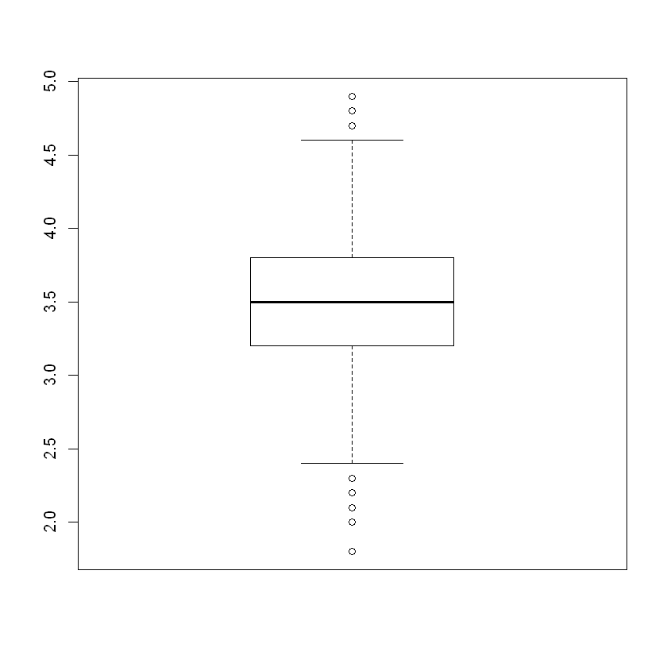

```r
boxplot(zomato$rate)
```

### description

Rating depend in the reviewer's preferences, these ratings are subjective and can change over time, by this boxplot we can determine the outliers which are few.

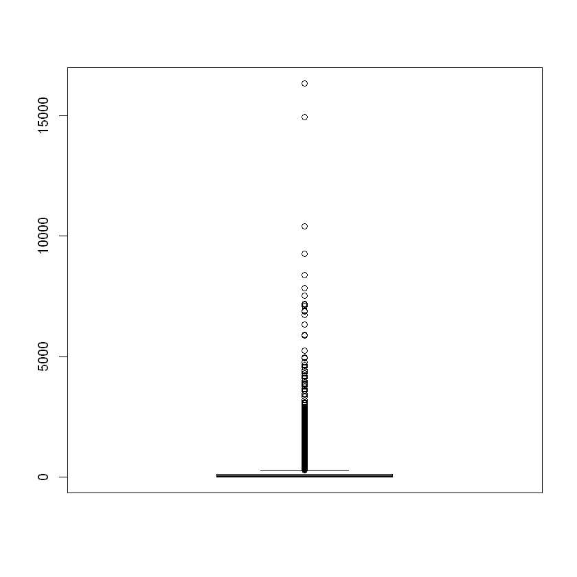

```r
boxplot(zomato$numofratings)
```

### description:

The number of rating boxplot shows that value are close and there hug verity of numbers and a lot of ouliers.

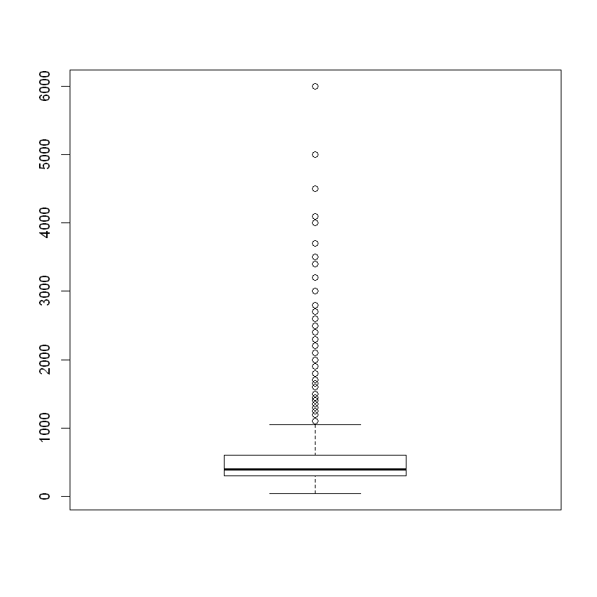

```r
boxplot(zomato$avgCost)
```

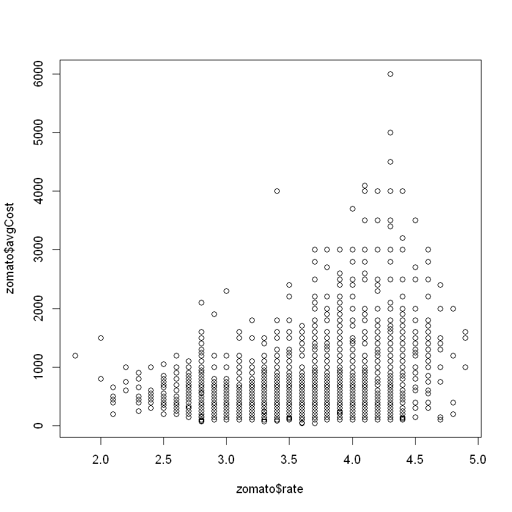

```r
plot(zomato$rate,zomato$avgCost)
```

scatterplot visualiz the relationship between two variables and identifying patterns or trends in the data, in this scatterplot we can see that there is few outlier and the higher the rate the higher the cost.

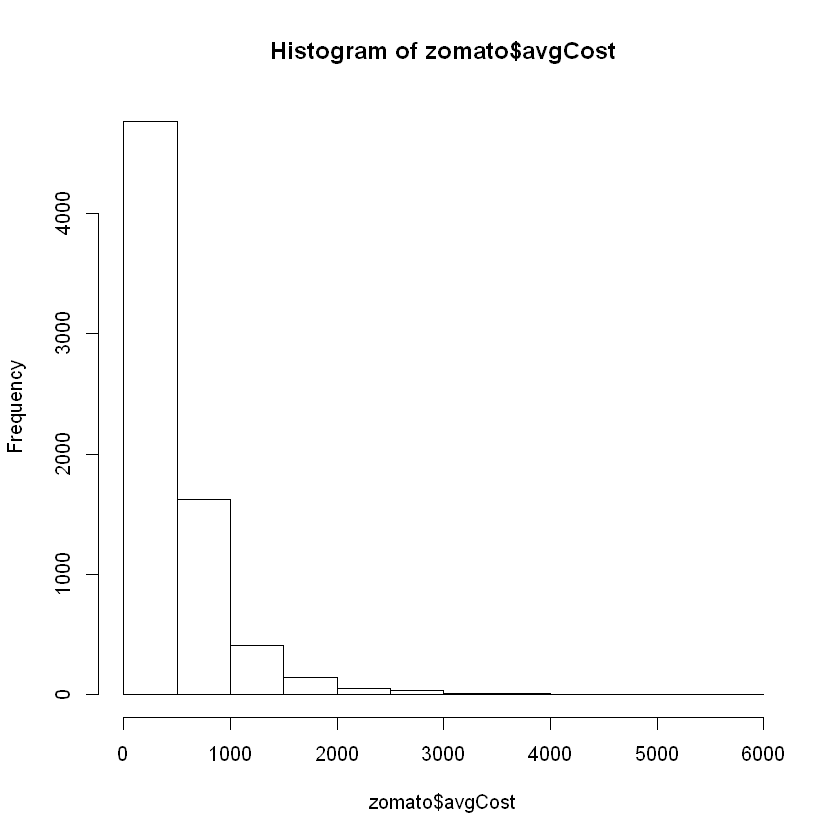

```r
hist(zomato$avgCost)
```

The following histogram represents the frequency of the average of two people, we noticed that most values frequency falls in 0-500 .

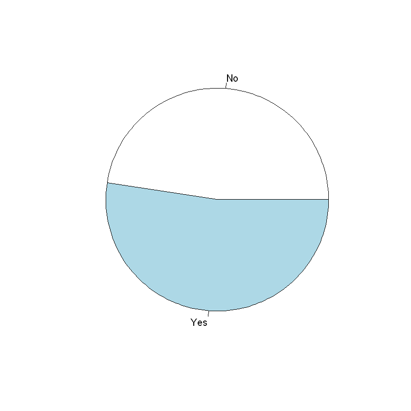

```r
onlineOrder <- table(zomato$online_order)
pie(onlineOrder)
```

The pie chart represents the percentage of the restaurants that allow and provide online ordering or not, we can see slight difference between the two.

## Statistical Measures

```r
summary (zomato$rate)
```

```
   Min. 1st Qu.  Median    Mean 3rd Qu.    Max.    NA's
  1.800   3.200   3.500   3.514   3.800   4.900      68
```

```r
summary(zomato$numofratings)
```

```
   Min. 1st Qu.  Median    Mean 3rd Qu.    Max.
    1.0    16.0    40.0   188.9   128.0 16345.0
```

```r
summary(zomato$avgCost)
```

```
   Min. 1st Qu.  Median    Mean 3rd Qu.    Max.    NA's
   40.0   300.0   400.0   540.3   600.0  6000.0      57
```

### Check for missing value:

```r
dim(zomato)
```

1. 7105

2. 12

```r
zomato =na.omit(zomato)
```

```r
dim(zomato)
```

1. 6984

2. 12

```r
sum(is.na(zomato))
```

0

### Description:

Missing or null values can significantly impact the effectiveness of a dataset and the quality of insights that can be derived from it. Therefore, we conducted an examination of our data to identify and eliminate any rows containing missing or null values. This process was undertaken to enhance the overall efficiency and reliability of our dataset, ensuring more accurate analysis and valuable information extraction in subsequent steps.

## Detecting and removing the outliers

### Detecting the outliers:

Initially, we detected any unusual data points in the numerical attributes. Subsequently, we removed the rows containing these outliers in order to create a more precise dataset, which would ultimately enhance the accuracy of our later results.

```r
library(outliers)
```

Detect outliers in the 'numofratings' column of the 'zomato' dataset.

```r
OutN = outlier(zomato$numofratings, logical =TRUE)
```

Sum the number of outliers detected.

```r
sum(OutN)
```

1

Find the indices of the outliers in the 'numofratings' column.

```r
Find_outlier = which(OutN ==TRUE, arr.ind = TRUE)
```

Display the logical vector indicating outliers.

```r
OutN
```

3. FALSE

4. FALSE

5. FALSE

6. FALSE

7. FALSE

8. FALSE

9. FALSE

10. FALSE

11. FALSE

12. FALSE

13. FALSE

14. FALSE

15. FALSE

16. FALSE

17. FALSE

18. FALSE

19. FALSE

20. FALSE

21. FALSE

22. FALSE

23. FALSE

24. FALSE

25. FALSE

26. FALSE

27. FALSE

28. FALSE

29. FALSE

30. FALSE

31. FALSE

32. FALSE

33. FALSE

34. FALSE

35. FALSE

36. FALSE

37. FALSE

38. FALSE

39. FALSE

40. FALSE

41. FALSE

42. FALSE

43. FALSE

44. FALSE

45. FALSE

46. FALSE

47. FALSE

48. FALSE

49. FALSE

50. FALSE

51. FALSE

52. FALSE

53. FALSE

54. FALSE

55. FALSE

56. FALSE

57. FALSE

58. FALSE

59. FALSE

60. FALSE

61. FALSE

62. FALSE

63. FALSE

64. FALSE

65. FALSE

66. FALSE

67. FALSE

68. FALSE

69. FALSE

70. FALSE

71. FALSE

72. FALSE

73. FALSE

74. FALSE

75. FALSE

76. FALSE

77. FALSE

78. FALSE

79. FALSE

80. FALSE

81. FALSE

82. FALSE

83. FALSE

84. FALSE

85. FALSE

86. FALSE

87. FALSE

88. FALSE

89. FALSE

90. FALSE

91. FALSE

92. FALSE

93. FALSE

94. FALSE

95. FALSE

96. FALSE

97. FALSE

98. FALSE

99. FALSE

100. FALSE

101. FALSE

102. FALSE

103. FALSE

104. FALSE

105. FALSE

106. FALSE

107. FALSE

108. FALSE

109. FALSE

110. FALSE

111. FALSE

112. FALSE

113. FALSE

114. FALSE

115. FALSE

116. FALSE

117. FALSE

118. FALSE

119. FALSE

120. FALSE

121. FALSE

122. FALSE

123. FALSE

124. FALSE

125. FALSE

126. FALSE

127. FALSE

128. FALSE

129. FALSE

130. FALSE

131. FALSE

132. FALSE

133. FALSE

134. FALSE

135. FALSE

136. FALSE

137. FALSE

138. FALSE

139. FALSE

140. FALSE

141. FALSE

142. FALSE

143. FALSE

144. FALSE

145. FALSE

146. FALSE

147. FALSE

148. FALSE

149. FALSE

150. FALSE

151. FALSE

152. FALSE

153. FALSE

154. FALSE

155. FALSE

156. FALSE

157. FALSE

158. FALSE

159. FALSE

160. FALSE

161. FALSE

162. FALSE

163. FALSE

164. FALSE

165. FALSE

166. FALSE

167. FALSE

168. FALSE

169. FALSE

170. FALSE

171. FALSE

172. FALSE

173. FALSE

174. FALSE

175. FALSE

176. FALSE

177. FALSE

178. FALSE

179. FALSE

180. FALSE

181. FALSE

182. FALSE

183. FALSE

184. FALSE

185. FALSE

186. FALSE

187. FALSE

188. FALSE

189. FALSE

190. FALSE

191. FALSE

192. FALSE

193. FALSE

194. FALSE

195. FALSE

196. FALSE

197. FALSE

198. FALSE

199. FALSE

200. FALSE

201. FALSE

202. FALSE

203. FALSE

204. FALSE

205. FALSE

206. FALSE

207. FALSE

208. FALSE

209. FALSE

210. FALSE

211. FALSE

212. FALSE

213. FALSE

214. FALSE

215. FALSE

216. FALSE

217. FALSE

218. FALSE

219. FALSE

220. FALSE

221. FALSE

222. FALSE

223. FALSE

224. FALSE

225. FALSE

226. FALSE

227. FALSE

228. FALSE

229. FALSE

230. FALSE

231. FALSE

232. FALSE

233. FALSE

234. FALSE

235. FALSE

236. FALSE

237. FALSE

238. FALSE

239. FALSE

240. FALSE

241. FALSE

242. FALSE

243. FALSE

244. FALSE

245. FALSE

246. FALSE

247. FALSE

248. FALSE

249. FALSE

250. FALSE

251. FALSE

252. FALSE

253. FALSE

254. FALSE

255. FALSE

256. FALSE

257. FALSE

258. FALSE

259. FALSE

260. FALSE

261. FALSE

262. FALSE

263. FALSE

264. FALSE

265. FALSE

266. FALSE

267. FALSE

268. FALSE

269. FALSE

270. FALSE

271. FALSE

272. FALSE

273. FALSE

274. FALSE

275. FALSE

276. FALSE

277. FALSE

278. FALSE

279. FALSE

280. FALSE

281. FALSE

282. FALSE

283. FALSE

284. FALSE

285. FALSE

286. FALSE

287. FALSE

288. FALSE

289. FALSE

290. FALSE

291. FALSE

292. FALSE

293. FALSE

294. FALSE

295. FALSE

296. FALSE

297. FALSE

298. FALSE

299. FALSE

300. FALSE

301. FALSE

302. FALSE

303. FALSE

304. FALSE

305. FALSE

306. FALSE

307. FALSE

308. FALSE

309. FALSE

310. FALSE

311. FALSE

312. FALSE

313. FALSE

314. FALSE

315. FALSE

316. FALSE

317. FALSE

318. FALSE

319. FALSE

320. FALSE

321. FALSE

322. FALSE

323. FALSE

324. FALSE

325. FALSE

326. FALSE

327. FALSE

328. FALSE

329. FALSE

330. FALSE

331. FALSE

332. FALSE

333. FALSE

334. FALSE

335. FALSE

336. FALSE

337. FALSE

338. FALSE

339. FALSE

340. FALSE

341. FALSE

342. FALSE

343. FALSE

344. FALSE

345. FALSE

346. FALSE

347. FALSE

348. FALSE

349. FALSE

350. FALSE

351. FALSE

352. FALSE

353. FALSE

354. FALSE

355. FALSE

356. FALSE

357. FALSE

358. FALSE

359. FALSE

360. FALSE

361. FALSE

362. FALSE

363. FALSE

364. FALSE

365. FALSE

366. FALSE

367. FALSE

368. FALSE

369. FALSE

370. FALSE

371. FALSE

372. FALSE

373. FALSE

374. FALSE

375. FALSE

376. FALSE

377. FALSE

378. FALSE

379. FALSE

380. FALSE

381. FALSE

382. FALSE

383. FALSE

384. FALSE

385. FALSE

386. FALSE

387. FALSE

388. FALSE

389. FALSE

390. FALSE

391. FALSE

392. FALSE

393. FALSE

394. FALSE

395. FALSE

396. FALSE

397. FALSE

398. FALSE

399. FALSE

400. FALSE

401. FALSE

402. FALSE

403. FALSE

404. FALSE

405. FALSE

406. FALSE

407. FALSE

408. FALSE

409. FALSE

410. FALSE

411. FALSE

412. FALSE

413. FALSE

414. FALSE

415. FALSE

416. FALSE

417. FALSE

418. FALSE

419. FALSE

420. FALSE

421. FALSE

422. FALSE

423. FALSE

424. FALSE

425. FALSE

426. FALSE

427. FALSE

428. FALSE

429. FALSE

430. FALSE

431. FALSE

432. FALSE

433. FALSE

434. FALSE

435. FALSE

436. FALSE

437. FALSE

438. FALSE

439. FALSE

440. FALSE

441. FALSE

442. FALSE

443. FALSE

444. FALSE

445. FALSE

446. FALSE

447. FALSE

448. FALSE

449. FALSE

450. FALSE

451. FALSE

452. FALSE

453. FALSE

454. FALSE

455. FALSE

456. FALSE

457. FALSE

458. FALSE

459. FALSE

460. FALSE

461. FALSE

462. FALSE

463. FALSE

464. FALSE

465. FALSE

466. FALSE

467. FALSE

468. FALSE

469. FALSE

470. FALSE

471. FALSE

472. FALSE

473. FALSE

474. FALSE

475. FALSE

476. FALSE

477. FALSE

478. FALSE

479. FALSE

480. FALSE

481. FALSE

482. FALSE

483. FALSE

484. FALSE

485. FALSE

486. FALSE

487. FALSE

488. FALSE

489. FALSE

490. FALSE

491. FALSE

492. FALSE

493. FALSE

494. FALSE

495. FALSE

496. FALSE

497. FALSE

498. FALSE

499. FALSE

500. FALSE

501. FALSE

502. FALSE

503. FALSE

504. FALSE

505. FALSE

506. FALSE

507. FALSE

508. FALSE

509. FALSE

510. FALSE

511. FALSE

512. FALSE

513. FALSE

514. FALSE

515. FALSE

516. FALSE

517. FALSE

518. FALSE

519. FALSE

520. FALSE

521. FALSE

522. FALSE

523. FALSE

524. FALSE

525. FALSE

526. FALSE

527. FALSE

528. FALSE

529. FALSE

530. FALSE

531. FALSE

532. FALSE

533. FALSE

534. FALSE

535. FALSE

536. FALSE

537. FALSE

538. FALSE

539. FALSE

540. FALSE

541. FALSE

542. FALSE

543. FALSE

544. FALSE

545. FALSE

546. FALSE

547. FALSE

548. FALSE

549. FALSE

550. FALSE

551. FALSE

552. FALSE

553. FALSE

554. FALSE

555. FALSE

556. FALSE

557. FALSE

558. FALSE

559. FALSE

560. FALSE

561. FALSE

562. FALSE

563. FALSE

564. FALSE

565. FALSE

566. FALSE

567. FALSE

568. FALSE

569. FALSE

570. FALSE

571. FALSE

572. FALSE

573. FALSE

574. FALSE

575. FALSE

576. FALSE

577. FALSE

578. FALSE

579. FALSE

580. FALSE

581. FALSE

582. FALSE

583. FALSE

584. FALSE

585. FALSE

586. FALSE

587. FALSE

588. FALSE

589. FALSE

590. FALSE

591. FALSE

592. FALSE

593. FALSE

594. FALSE

595. FALSE

596. FALSE

597. FALSE

598. FALSE

599. FALSE

600. FALSE

601. FALSE

602. FALSE

603. FALSE

604. FALSE

605. FALSE

606. FALSE

607. FALSE

608. FALSE

609. FALSE

610. FALSE

611. FALSE

612. FALSE

613. FALSE

614. FALSE

615. FALSE

616. FALSE

617. FALSE

618. FALSE

619. FALSE

620. FALSE

621. FALSE

622. FALSE

623. FALSE

624. FALSE

625. FALSE

626. FALSE

627. FALSE

628. FALSE

629. FALSE

630. FALSE

631. FALSE

632. FALSE

633. FALSE

634. FALSE

635. FALSE

636. FALSE

637. FALSE

638. FALSE

639. FALSE

640. FALSE

641. FALSE

642. FALSE

643. FALSE

644. FALSE

645. FALSE

646. FALSE

647. FALSE

648. FALSE

649. FALSE

650. FALSE

651. FALSE

652. FALSE

653. FALSE

654. FALSE

655. FALSE

656. FALSE

657. FALSE

658. FALSE

659. FALSE

660. FALSE

661. FALSE

662. FALSE

663. FALSE

664. FALSE

665. FALSE

666. FALSE

667. FALSE

668. FALSE

669. FALSE

670. FALSE

671. FALSE

672. FALSE

673. FALSE

674. FALSE

675. FALSE

676. FALSE

677. FALSE

678. FALSE

679. FALSE

680. FALSE

681. FALSE

682. FALSE

683. FALSE

684. FALSE

685. FALSE

686. FALSE

687. FALSE

688. FALSE

689. FALSE

690. FALSE

691. FALSE

692. FALSE

693. FALSE

694. FALSE

695. FALSE

696. FALSE

697. FALSE

698. FALSE

699. FALSE

700. FALSE

701. FALSE

702. FALSE

703. FALSE

704. FALSE

705. FALSE

706. FALSE

707. FALSE

708. FALSE

709. FALSE

710. FALSE

711. FALSE

712. FALSE

713. FALSE

714. FALSE

715. FALSE

716. FALSE

717. FALSE

718. FALSE

719. FALSE

720. FALSE

721. FALSE

722. FALSE

723. FALSE

724. FALSE

725. FALSE

726. FALSE

727. FALSE

728. FALSE

729. FALSE

730. FALSE

731. FALSE

732. FALSE

733. FALSE

734. FALSE

735. FALSE

736. FALSE

737. FALSE

738. FALSE

739. FALSE

740. FALSE

741. FALSE

742. FALSE

743. FALSE

744. FALSE

745. FALSE

746. FALSE

747. FALSE

748. FALSE

749. FALSE

750. FALSE

751. FALSE

752. FALSE

753. FALSE

754. FALSE

755. FALSE

756. FALSE

757. FALSE

758. FALSE

759. FALSE

760. FALSE

761. FALSE

762. FALSE

763. FALSE

764. FALSE

765. FALSE

766. FALSE

767. FALSE

768. FALSE

769. FALSE

770. FALSE

771. FALSE

772. FALSE

773. FALSE

774. FALSE

775. FALSE

776. FALSE

777. FALSE

778. FALSE

779. FALSE

780. FALSE

781. FALSE

782. FALSE

783. FALSE

784. FALSE

785. FALSE

786. FALSE

787. FALSE

788. FALSE

789. FALSE

790. FALSE

791. FALSE

792. FALSE

793. FALSE

794. FALSE

795. FALSE

796. FALSE

797. FALSE

798. FALSE

799. FALSE

800. FALSE

801. FALSE

802. FALSE

803. FALSE

804. FALSE

805. FALSE

806. FALSE

807. FALSE

808. FALSE

809. FALSE

810. FALSE

811. FALSE

812. FALSE

813. FALSE

814. FALSE

815. FALSE

816. FALSE

817. FALSE

818. FALSE

819. FALSE

820. FALSE

821. FALSE

822. FALSE

823. FALSE

824. FALSE

825. FALSE

826. FALSE

827. FALSE

828. FALSE

829. FALSE

830. FALSE

831. FALSE

832. FALSE

833. FALSE

834. FALSE

835. FALSE

836. FALSE

837. FALSE

838. FALSE

839. FALSE

840. FALSE

841. FALSE

842. FALSE

843. FALSE

844. FALSE

845. FALSE

846. FALSE

847. FALSE

848. FALSE

849. FALSE

850. FALSE

851. FALSE

852. FALSE

853. FALSE

854. FALSE

855. FALSE

856. FALSE

857. FALSE

858. FALSE

859. FALSE

860. FALSE

861. FALSE

862. FALSE

863. FALSE

864. FALSE

865. FALSE

866. FALSE

867. FALSE

868. FALSE

869. FALSE

870. FALSE

871. FALSE

872. FALSE

873. FALSE

874. FALSE

875. FALSE

876. FALSE

877. FALSE

878. FALSE

879. FALSE

880. FALSE

881. FALSE

882. FALSE

883. FALSE

884. FALSE

885. FALSE

886. FALSE

887. FALSE

888. FALSE

889. FALSE

890. FALSE

891. FALSE

892. FALSE

893. FALSE

894. FALSE

895. FALSE

896. FALSE

897. FALSE

898. FALSE

899. FALSE

900. FALSE

901. FALSE

902. FALSE

903. FALSE

904. FALSE

905. FALSE

906. FALSE

907. FALSE

908. FALSE

909. FALSE

910. FALSE

911. FALSE

912. FALSE

913. FALSE

914. FALSE

915. FALSE

916. FALSE

917. FALSE

918. FALSE

919. FALSE

920. FALSE

921. FALSE

922. FALSE

923. FALSE

924. FALSE

925. FALSE

926. FALSE

927. FALSE

928. FALSE

929. FALSE

930. FALSE

931. FALSE

932. FALSE

933. FALSE

934. FALSE

935. FALSE

936. FALSE

937. FALSE

938. FALSE

939. FALSE

940. FALSE

941. FALSE

942. FALSE

943. FALSE

944. FALSE

945. FALSE

946. FALSE

947. FALSE

948. FALSE

949. FALSE

950. FALSE

951. FALSE

952. FALSE

953. FALSE

954. FALSE

955. FALSE

956. FALSE

957. FALSE

958. FALSE

959. FALSE

960. FALSE

961. FALSE

962. FALSE

963. FALSE

964. FALSE

965. FALSE

966. FALSE

967. FALSE

968. FALSE

969. FALSE

970. FALSE

971. FALSE

972. FALSE

973. FALSE

974. FALSE

975. FALSE

976. FALSE

977. FALSE

978. FALSE

979. FALSE

980. FALSE

981. FALSE

982. FALSE

983. FALSE

984. FALSE

985. FALSE

986. FALSE

987. FALSE

988. FALSE

989. FALSE

990. FALSE

991. FALSE

992. FALSE

993. FALSE

994. FALSE

995. FALSE

996. FALSE

997. FALSE

998. FALSE

999. FALSE

1000. FALSE

1001. FALSE

1002. FALSE

1003. FALSE

1004. FALSE

1005. FALSE

1006. FALSE

1007. FALSE

1008. FALSE

1009. FALSE

1010. FALSE

1011. FALSE

1012. FALSE

1013. FALSE

1014. FALSE

1015. FALSE

1016. FALSE

1017. FALSE

1018. FALSE

1019. TRUE

1020. FALSE

1021. FALSE

1022. FALSE

1023. FALSE

1024. FALSE

1025. FALSE

1026. FALSE

1027. FALSE

1028. FALSE

1029. FALSE

1030. FALSE

1031. FALSE

1032. FALSE

1033. FALSE

1034. FALSE

1035. FALSE

1036. FALSE

1037. FALSE

1038. FALSE

1039. FALSE

1040. FALSE

1041. FALSE

1042. FALSE

1043. FALSE

1044. FALSE

1045. FALSE

1046. FALSE

1047. FALSE

1048. FALSE

1049. FALSE

1050. FALSE

1051. FALSE

1052. FALSE

1053. FALSE

1054. FALSE

1055. FALSE

1056. FALSE

1057. FALSE

1058. FALSE

1059. FALSE

1060. FALSE

1061. FALSE

1062. FALSE

1063. FALSE

1064. FALSE

1065. FALSE

1066. FALSE

1067. FALSE

1068. FALSE

1069. FALSE

1070. FALSE

1071. FALSE

1072. FALSE

1073. FALSE

1074. FALSE

1075. FALSE

1076. FALSE

1077. FALSE

1078. FALSE

1079. FALSE

1080. FALSE

1081. FALSE

1082. FALSE

1083. FALSE

1084. FALSE

1085. FALSE

1086. FALSE

1087. FALSE

1088. FALSE

1089. FALSE

1090. FALSE

1091. FALSE

1092. FALSE

1093. FALSE

1094. FALSE

1095. FALSE

1096. FALSE

1097. FALSE

1098. FALSE

1099. FALSE

1100. FALSE

1101. FALSE

1102. FALSE

1103. FALSE

1104. FALSE

1105. FALSE

1106. FALSE

1107. FALSE

1108. FALSE

1109. FALSE

1110. FALSE

1111. FALSE

1112. FALSE

1113. FALSE

1114. FALSE

1115. FALSE

1116. FALSE

1117. FALSE

1118. FALSE

1119. FALSE

1120. FALSE

1121. FALSE

1122. FALSE

1123. FALSE

1124. FALSE

1125. FALSE

1126. FALSE

1127. FALSE

1128. FALSE

1129. FALSE

1130. FALSE

1131. FALSE

1132. FALSE

1133. FALSE

1134. FALSE

1135. FALSE

1136. FALSE

1137. FALSE

1138. FALSE

1139. FALSE

1140. FALSE

1141. FALSE

1142. FALSE

1143. FALSE

1144. FALSE

1145. FALSE

1146. FALSE

1147. FALSE

1148. FALSE

1149. FALSE

1150. FALSE

1151. FALSE

1152. FALSE

1153. FALSE

1154. FALSE

1155. FALSE

1156. FALSE

1157. FALSE

1158. FALSE

1159. FALSE

1160. FALSE

1161. FALSE

1162. FALSE

1163. FALSE

1164. FALSE

1165. FALSE

1166. FALSE

1167. FALSE

1168. FALSE

1169. FALSE

1170. FALSE

1171. FALSE

1172. FALSE

1173. FALSE

1174. FALSE

1175. FALSE

1176. FALSE

1177. FALSE

1178. FALSE

1179. FALSE

1180. FALSE

1181. FALSE

1182. FALSE

1183. FALSE

1184. FALSE

1185. FALSE

1186. FALSE

1187. FALSE

1188. FALSE

1189. FALSE

1190. FALSE

1191. FALSE

1192. FALSE

1193. FALSE

1194. FALSE

1195. FALSE

1196. FALSE

1197. FALSE

1198. FALSE

1199. FALSE

1200. FALSE

1201. FALSE

1202. FALSE

1203. FALSE

1204. FALSE

1205. FALSE

1206. FALSE

1207. FALSE

1208. FALSE

1209. FALSE

1210. FALSE

1211. FALSE

1212. FALSE

1213. FALSE

1214. FALSE

1215. FALSE

1216. FALSE

1217. FALSE

1218. FALSE

1219. FALSE

1220. FALSE

1221. FALSE

1222. FALSE

1223. FALSE

1224. FALSE

1225. FALSE

1226. FALSE

1227. FALSE

1228. FALSE

1229. FALSE

1230. FALSE

1231. FALSE

1232. FALSE

1233. FALSE

1234. FALSE

1235. FALSE

1236. FALSE

1237. FALSE

1238. FALSE

1239. FALSE

1240. FALSE

1241. FALSE

1242. FALSE

1243. FALSE

1244. FALSE

1245. FALSE

1246. FALSE

1247. FALSE

1248. FALSE

1249. FALSE

1250. FALSE

1251. FALSE

1252. FALSE

1253. FALSE

1254. FALSE

1255. FALSE

1256. FALSE

1257. FALSE

1258. FALSE

1259. FALSE

1260. FALSE

1261. FALSE

1262. FALSE

1263. FALSE

1264. FALSE

1265. FALSE

1266. FALSE

1267. FALSE

1268. FALSE

1269. FALSE

1270. FALSE

1271. FALSE

1272. FALSE

1273. FALSE

1274. FALSE

1275. FALSE

1276. FALSE

1277. FALSE

1278. FALSE

1279. FALSE

1280. FALSE

1281. FALSE

1282. FALSE

1283. FALSE

1284. FALSE

1285. FALSE

1286. FALSE

1287. FALSE

1288. FALSE

1289. FALSE

1290. FALSE

1291. FALSE

1292. FALSE

1293. FALSE

1294. FALSE

1295. FALSE

1296. FALSE

1297. FALSE

1298. FALSE

1299. FALSE

1300. FALSE

1301. FALSE

1302. FALSE

1303. FALSE

1304. FALSE

1305. FALSE

1306. FALSE

1307. FALSE

1308. FALSE

1309. FALSE

1310. FALSE

1311. FALSE

1312. FALSE

1313. FALSE

1314. FALSE

1315. FALSE

1316. FALSE

1317. FALSE

1318. FALSE

1319. FALSE

1320. FALSE

1321. FALSE

1322. FALSE

1323. FALSE

1324. FALSE

1325. FALSE

1326. FALSE

1327. FALSE

1328. FALSE

1329. FALSE

1330. FALSE

1331. FALSE

1332. FALSE

1333. FALSE

1334. FALSE

1335. FALSE

1336. FALSE

1337. FALSE

1338. FALSE

1339. FALSE

1340. FALSE

1341. FALSE

1342. FALSE

1343. FALSE

1344. FALSE

1345. FALSE

1346. FALSE

1347. FALSE

1348. FALSE

1349. FALSE

1350. FALSE

1351. FALSE

1352. FALSE

1353. FALSE

1354. FALSE

1355. FALSE

1356. FALSE

1357. FALSE

1358. FALSE

1359. FALSE

1360. FALSE

1361. FALSE

1362. FALSE

1363. FALSE

1364. FALSE

1365. FALSE

1366. FALSE

1367. FALSE

1368. FALSE

1369. FALSE

1370. FALSE

1371. FALSE

1372. FALSE

1373. FALSE

1374. FALSE

1375. FALSE

1376. FALSE

1377. FALSE

1378. FALSE

1379. FALSE

1380. FALSE

1381. FALSE

1382. FALSE

1383. FALSE

1384. FALSE

1385. FALSE

1386. FALSE

1387. FALSE

1388. FALSE

1389. FALSE

1390. FALSE

1391. FALSE

1392. FALSE

1393. FALSE

1394. FALSE

1395. FALSE

1396. FALSE

1397. FALSE

1398. FALSE

1399. FALSE

1400. FALSE

1401. FALSE

1402. FALSE

1403. FALSE

1404. FALSE

1405. FALSE

1406. FALSE

1407. FALSE

1408. FALSE

1409. FALSE

1410. FALSE

1411. FALSE

1412. FALSE

1413. FALSE

1414. FALSE

1415. FALSE

1416. FALSE

1417. FALSE

1418. FALSE

1419. FALSE

1420. FALSE

1421. FALSE

1422. FALSE

1423. FALSE

1424. FALSE

1425. FALSE

1426. FALSE

1427. FALSE

1428. FALSE

1429. FALSE

1430. FALSE

1431. FALSE

1432. FALSE

1433. FALSE

1434. FALSE

1435. FALSE

1436. FALSE

1437. FALSE

1438. FALSE

1439. FALSE

1440. FALSE

1441. FALSE

1442. FALSE

1443. FALSE

1444. FALSE

1445. FALSE

1446. FALSE

1447. FALSE

1448. FALSE

1449. FALSE

1450. FALSE

1451. FALSE

1452. FALSE

1453. FALSE

1454. FALSE

1455. FALSE

1456. FALSE

1457. FALSE

1458. FALSE

1459. FALSE

1460. FALSE

1461. FALSE

1462. FALSE

1463. FALSE

1464. FALSE

1465. FALSE

1466. FALSE

1467. FALSE

1468. FALSE

1469. FALSE

1470. FALSE

1471. FALSE

1472. FALSE

1473. FALSE

1474. FALSE

1475. FALSE

1476. FALSE

1477. FALSE

1478. FALSE

1479. FALSE

1480. FALSE

1481. FALSE

1482. FALSE

1483. FALSE

1484. FALSE

1485. FALSE

1486. FALSE

1487. FALSE

1488. FALSE

1489. FALSE

1490. FALSE

1491. FALSE

1492. FALSE

1493. FALSE

1494. FALSE

1495. FALSE

1496. FALSE

1497. FALSE

1498. FALSE

1499. FALSE

1500. FALSE

1501. FALSE

1502. FALSE

1503. FALSE

1504. FALSE

1505. FALSE

1506. FALSE

1507. FALSE

1508. FALSE

1509. FALSE

1510. FALSE

1511. FALSE

1512. FALSE

1513. FALSE

1514. FALSE

1515. FALSE

1516. FALSE

1517. FALSE

1518. FALSE

1519. FALSE

1520. FALSE

1521. FALSE

1522. FALSE

1523. FALSE

1524. FALSE

1525. FALSE

1526. FALSE

1527. FALSE

1528. FALSE

1529. FALSE

1530. FALSE

1531. FALSE

1532. FALSE

1533. FALSE

1534. FALSE

1535. FALSE

1536. FALSE

1537. FALSE

1538. FALSE

1539. FALSE

1540. FALSE

1541. FALSE

1542. FALSE

1543. FALSE

1544. FALSE

1545. FALSE

1546. FALSE

1547. FALSE

1548. FALSE

1549. FALSE

1550. FALSE

1551. FALSE

1552. FALSE

1553. FALSE

1554. FALSE

1555. FALSE

1556. FALSE

1557. FALSE

1558. FALSE

1559. FALSE

1560. FALSE

1561. FALSE

1562. FALSE

1563. FALSE

1564. FALSE

1565. FALSE

1566. FALSE

1567. FALSE

1568. FALSE

1569. FALSE

1570. FALSE

1571. FALSE

1572. FALSE

1573. FALSE

1574. FALSE

1575. FALSE

1576. FALSE

1577. FALSE

1578. FALSE

1579. FALSE

1580. FALSE

1581. FALSE

1582. FALSE

1583. FALSE

1584. FALSE

1585. FALSE

1586. FALSE

1587. FALSE

1588. FALSE

1589. FALSE

1590. FALSE

1591. FALSE

1592. FALSE

1593. FALSE

1594. FALSE

1595. FALSE

1596. FALSE

1597. FALSE

1598. FALSE

1599. FALSE

1600. FALSE

1601. FALSE

1602. FALSE

1603. FALSE

1604. FALSE

1605. FALSE

1606. FALSE

1607. FALSE

1608. FALSE

1609. FALSE

1610. FALSE

1611. FALSE

1612. FALSE

1613. FALSE

1614. FALSE

1615. FALSE

1616. FALSE

1617. FALSE

1618. FALSE

1619. FALSE

1620. FALSE

1621. FALSE

1622. FALSE

1623. FALSE

1624. FALSE

1625. FALSE

1626. FALSE

1627. FALSE

1628. FALSE

1629. FALSE

1630. FALSE

1631. FALSE

1632. FALSE

1633. FALSE

1634. FALSE

1635. FALSE

1636. FALSE

1637. FALSE

1638. FALSE

1639. FALSE

1640. FALSE

1641. FALSE

1642. FALSE

1643. FALSE

1644. FALSE

1645. FALSE

1646. FALSE

1647. FALSE

1648. FALSE

1649. FALSE

1650. FALSE

1651. FALSE

1652. FALSE

1653. FALSE

1654. FALSE

1655. FALSE

1656. FALSE

1657. FALSE

1658. FALSE

1659. FALSE

1660. FALSE

1661. FALSE

1662. FALSE

1663. FALSE

1664. FALSE

1665. FALSE

1666. FALSE

1667. FALSE

1668. FALSE

1669. FALSE

1670. FALSE

1671. FALSE

1672. FALSE

1673. FALSE

1674. FALSE

1675. FALSE

1676. FALSE

1677. FALSE

1678. FALSE

1679. FALSE

1680. FALSE

1681. FALSE

1682. FALSE

1683. FALSE

1684. FALSE

1685. FALSE

1686. FALSE

1687. FALSE

1688. FALSE

1689. FALSE

1690. FALSE

1691. FALSE

1692. FALSE

1693. FALSE

1694. FALSE

1695. FALSE

1696. FALSE

1697. FALSE

1698. FALSE

1699. FALSE

1700. FALSE

1701. FALSE

1702. FALSE

1703. FALSE

1704. FALSE

1705. FALSE

1706. FALSE

1707. FALSE

1708. FALSE

1709. FALSE

1710. FALSE

1711. FALSE

1712. FALSE

1713. FALSE

1714. FALSE

1715. FALSE

1716. FALSE

1717. FALSE

1718. FALSE

1719. FALSE

1720. FALSE

1721. FALSE

1722. FALSE

1723. FALSE

1724. FALSE

1725. FALSE

1726. FALSE

1727. FALSE

1728. FALSE

1729. FALSE

1730. FALSE

1731. FALSE

1732. FALSE

1733. FALSE

1734. FALSE

1735. FALSE

1736. FALSE

1737. FALSE

1738. FALSE

1739. FALSE

1740. FALSE

1741. FALSE

1742. FALSE

1743. FALSE

1744. FALSE

1745. FALSE

1746. FALSE

1747. FALSE

1748. FALSE

1749. FALSE

1750. FALSE

1751. FALSE

1752. FALSE

1753. FALSE

1754. FALSE

1755. FALSE

1756. FALSE

1757. FALSE

1758. FALSE

1759. FALSE

1760. FALSE

1761. FALSE

1762. FALSE

1763. FALSE

1764. FALSE

1765. FALSE

1766. FALSE

1767. FALSE

1768. FALSE

1769. FALSE

1770. FALSE

1771. FALSE

1772. FALSE

1773. FALSE

1774. FALSE

1775. FALSE

1776. FALSE

1777. FALSE

1778. FALSE

1779. FALSE

1780. FALSE

1781. FALSE

1782. FALSE

1783. FALSE

1784. FALSE

1785. FALSE

1786. FALSE

1787. FALSE

1788. FALSE

1789. FALSE

1790. FALSE

1791. FALSE

1792. FALSE

1793. FALSE

1794. FALSE

1795. FALSE

1796. FALSE

1797. FALSE

1798. FALSE

1799. FALSE

1800. FALSE

1801. FALSE

1802. FALSE

1803. FALSE

1804. FALSE

1805. FALSE

1806. FALSE

1807. FALSE

1808. FALSE

1809. FALSE

1810. FALSE

1811. FALSE

1812. FALSE

1813. FALSE

1814. FALSE

1815. FALSE

1816. FALSE

1817. FALSE

1818. FALSE

1819. FALSE

1820. FALSE

1821. FALSE

1822. FALSE

1823. FALSE

1824. FALSE

1825. FALSE

1826. FALSE

1827. FALSE

1828. FALSE

1829. FALSE

1830. FALSE

1831. FALSE

1832. FALSE

1833. FALSE

1834. FALSE

1835. FALSE

1836. FALSE

1837. FALSE

1838. FALSE

1839. FALSE

1840. FALSE

1841. FALSE

1842. FALSE

1843. FALSE

1844. FALSE

1845. FALSE

1846. FALSE

1847. FALSE

1848. FALSE

1849. FALSE

1850. FALSE

1851. FALSE

1852. FALSE

1853. FALSE

1854. FALSE

1855. FALSE

1856. FALSE

1857. FALSE

1858. FALSE

1859. FALSE

1860. FALSE

1861. FALSE

1862. FALSE

1863. FALSE

1864. FALSE

1865. FALSE

1866. FALSE

1867. FALSE

1868. FALSE

1869. FALSE

1870. FALSE

1871. FALSE

1872. FALSE

1873. FALSE

1874. FALSE

1875. FALSE

1876. FALSE

1877. FALSE

1878. FALSE

1879. FALSE

1880. FALSE

1881. FALSE

1882. FALSE

1883. FALSE

1884. FALSE

1885. FALSE

1886. FALSE

1887. FALSE

1888. FALSE

1889. FALSE

1890. FALSE

1891. FALSE

1892. FALSE

1893. FALSE

1894. FALSE

1895. FALSE

1896. FALSE

1897. FALSE

1898. FALSE

1899. FALSE

1900. FALSE

1901. FALSE

1902. FALSE

1903. FALSE

1904. FALSE

1905. FALSE

1906. FALSE

1907. FALSE

1908. FALSE

1909. FALSE

1910. FALSE

1911. FALSE

1912. FALSE

1913. FALSE

1914. FALSE

1915. FALSE

1916. FALSE

1917. FALSE

1918. FALSE

1919. FALSE

1920. FALSE

1921. FALSE

1922. FALSE

1923. FALSE

1924. FALSE

1925. FALSE

1926. FALSE

1927. FALSE

1928. FALSE

1929. FALSE

1930. FALSE

1931. FALSE

1932. FALSE

1933. FALSE

1934. FALSE

1935. FALSE

1936. FALSE

1937. FALSE

1938. FALSE

1939. FALSE

1940. FALSE

1941. FALSE

1942. FALSE

1943. FALSE

1944. FALSE

1945. FALSE

1946. FALSE

1947. FALSE

1948. FALSE

1949. FALSE

1950. FALSE

1951. FALSE

1952. FALSE

1953. FALSE

1954. FALSE

1955. FALSE

1956. FALSE

1957. FALSE

1958. FALSE

1959. FALSE

1960. FALSE

1961. FALSE

1962. FALSE

1963. FALSE

1964. FALSE

1965. FALSE

1966. FALSE

1967. FALSE

1968. FALSE

1969. FALSE

1970. FALSE

1971. FALSE

1972. FALSE

1973. FALSE

1974. FALSE

1975. FALSE

1976. FALSE

1977. FALSE

1978. FALSE

1979. FALSE

1980. FALSE

1981. FALSE

1982. FALSE

1983. FALSE

1984. FALSE

1985. FALSE

1986. FALSE

1987. FALSE

1988. FALSE

1989. FALSE

1990. FALSE

1991. FALSE

1992. FALSE

1993. FALSE

1994. FALSE

1995. FALSE

1996. FALSE

1997. FALSE

1998. FALSE

1999. FALSE

2000. FALSE

2001. FALSE

2002. FALSE

2003. FALSE

2004. FALSE

2005. FALSE

2006. FALSE

2007. FALSE

2008. FALSE

2009. FALSE

2010. FALSE

2011. FALSE

2012. FALSE

2013. FALSE

2014. FALSE

2015. FALSE

2016. FALSE

2017. FALSE

2018. FALSE

2019. FALSE

2020. FALSE

2021. FALSE

2022. FALSE

2023. FALSE

2024. FALSE

2025. FALSE

2026. FALSE

2027. FALSE

2028. FALSE

2029. FALSE

2030. FALSE

2031. FALSE

2032. FALSE

2033. FALSE

2034. FALSE

2035. FALSE

2036. FALSE

2037. FALSE

2038. FALSE

2039. FALSE

2040. FALSE

2041. FALSE

2042. FALSE

2043. FALSE

2044. FALSE

2045. FALSE

2046. FALSE

2047. FALSE

2048. FALSE

2049. FALSE

2050. FALSE

2051. FALSE

2052. FALSE

2053. FALSE

2054. FALSE

2055. FALSE

2056. FALSE

2057. FALSE

2058. FALSE

2059. FALSE

2060. FALSE

2061. FALSE

2062. FALSE

2063. FALSE

2064. FALSE

2065. FALSE

2066. FALSE

2067. FALSE

2068. FALSE

2069. FALSE

2070. FALSE

2071. FALSE

2072. FALSE

2073. FALSE

2074. FALSE

2075. FALSE

2076. FALSE

2077. FALSE

2078. FALSE

2079. FALSE

2080. FALSE

2081. FALSE

2082. FALSE

2083. FALSE

2084. FALSE

2085. FALSE

2086. FALSE

2087. FALSE

2088. FALSE

2089. FALSE

2090. FALSE

2091. FALSE

2092. FALSE

2093. FALSE

2094. FALSE

2095. FALSE

2096. FALSE

2097. FALSE

2098. FALSE

2099. FALSE

2100. FALSE

2101. FALSE

2102. FALSE

2103. FALSE

2104. FALSE

2105. FALSE

2106. FALSE

2107. FALSE

2108. FALSE

2109. FALSE

2110. FALSE

2111. FALSE

2112. FALSE

2113. FALSE

2114. FALSE

2115. FALSE

2116. FALSE

2117. FALSE

2118. FALSE

2119. FALSE

2120. FALSE

2121. FALSE

2122. FALSE

2123. FALSE

2124. FALSE

2125. FALSE

2126. FALSE

2127. FALSE

2128. FALSE

2129. FALSE

2130. FALSE

2131. FALSE

2132. FALSE

2133. FALSE

2134. FALSE

2135. FALSE

2136. FALSE

2137. FALSE

2138. FALSE

2139. FALSE

2140. FALSE

2141. FALSE

2142. FALSE

2143. FALSE

2144. FALSE

2145. FALSE

2146. FALSE

2147. FALSE

2148. FALSE

2149. FALSE

2150. FALSE

2151. FALSE

2152. FALSE

2153. FALSE

2154. FALSE

2155. FALSE

2156. FALSE

2157. FALSE

2158. FALSE

2159. FALSE

2160. FALSE

2161. FALSE

2162. FALSE

2163. FALSE

2164. FALSE

2165. FALSE

2166. FALSE

2167. FALSE

2168. FALSE

2169. FALSE

2170. FALSE

2171. FALSE

2172. FALSE

2173. FALSE

2174. FALSE

2175. FALSE

2176. FALSE

2177. FALSE

2178. FALSE

2179. FALSE

2180. FALSE

2181. FALSE

2182. FALSE

2183. FALSE

2184. FALSE

2185. FALSE

2186. FALSE

2187. FALSE

2188. FALSE

2189. FALSE

2190. FALSE

2191. FALSE

2192. FALSE

2193. FALSE

2194. FALSE

2195. FALSE

2196. FALSE

2197. FALSE

2198. FALSE

2199. FALSE

2200. FALSE

2201. FALSE

2202. FALSE

2203. FALSE

2204. FALSE

2205. FALSE

2206. FALSE

2207. FALSE

2208. FALSE

2209. FALSE

2210. FALSE

2211. FALSE

2212. FALSE

2213. FALSE

2214. FALSE

2215. FALSE

2216. FALSE

2217. FALSE

2218. FALSE

2219. FALSE

2220. FALSE

2221. FALSE

2222. FALSE

2223. FALSE

2224. FALSE

2225. FALSE

2226. FALSE

2227. FALSE

2228. FALSE

2229. FALSE

2230. FALSE

2231. FALSE

2232. FALSE

2233. FALSE

2234. FALSE

2235. FALSE

2236. FALSE

2237. FALSE

2238. FALSE

2239. FALSE

2240. FALSE

2241. FALSE

2242. FALSE

2243. FALSE

2244. FALSE

2245. FALSE

2246. FALSE

2247. FALSE

2248. FALSE

2249. FALSE

2250. FALSE

2251. FALSE

2252. FALSE

2253. FALSE

2254. FALSE

2255. FALSE

2256. FALSE

2257. FALSE

2258. FALSE

2259. FALSE

2260. FALSE

2261. FALSE

2262. FALSE

2263. FALSE

2264. FALSE

2265. FALSE

2266. FALSE

2267. FALSE

2268. FALSE

2269. FALSE

2270. FALSE

2271. FALSE

2272. FALSE

2273. FALSE

2274. FALSE

2275. FALSE

2276. FALSE

2277. FALSE

2278. FALSE

2279. FALSE

2280. FALSE

2281. FALSE

2282. FALSE

2283. FALSE

2284. FALSE

2285. FALSE

2286. FALSE

2287. FALSE

2288. FALSE

2289. FALSE

2290. FALSE

2291. FALSE

2292. FALSE

2293. FALSE

2294. FALSE

2295. FALSE

2296. FALSE

2297. FALSE

2298. FALSE

2299. FALSE

2300. FALSE

2301. FALSE

2302. FALSE

2303. FALSE

2304. FALSE

2305. FALSE

2306. FALSE

2307. FALSE

2308. FALSE

2309. FALSE

2310. FALSE

2311. FALSE

2312. FALSE

2313. FALSE

2314. FALSE

2315. FALSE

2316. FALSE

2317. FALSE

2318. FALSE

2319. FALSE

2320. FALSE

2321. FALSE

2322. FALSE

2323. FALSE

2324. FALSE

2325. FALSE

2326. FALSE

2327. FALSE

2328. FALSE

2329. FALSE

2330. FALSE

2331. FALSE

2332. FALSE

2333. FALSE

2334. FALSE

2335. FALSE

2336. FALSE

2337. FALSE

2338. FALSE

2339. FALSE

2340. FALSE

2341. FALSE

2342. FALSE

2343. FALSE

2344. FALSE

2345. FALSE

2346. FALSE

2347. FALSE

2348. FALSE

2349. FALSE

2350. FALSE

2351. FALSE

2352. FALSE

2353. FALSE

2354. FALSE

2355. FALSE

2356. FALSE

2357. FALSE

2358. FALSE

2359. FALSE

2360. FALSE

2361. FALSE

2362. FALSE

2363. FALSE

2364. FALSE

2365. FALSE

2366. FALSE

2367. FALSE

2368. FALSE

2369. FALSE

2370. FALSE

2371. FALSE

2372. FALSE

2373. FALSE

2374. FALSE

2375. FALSE

2376. FALSE

2377. FALSE

2378. FALSE

2379. FALSE

2380. FALSE

2381. FALSE

2382. FALSE

2383. FALSE

2384. FALSE

2385. FALSE

2386. FALSE

2387. FALSE

2388. FALSE

2389. FALSE

2390. FALSE

2391. FALSE

2392. FALSE

2393. FALSE

2394. FALSE

2395. FALSE

2396. FALSE

2397. FALSE

2398. FALSE

2399. FALSE

2400. FALSE

2401. FALSE

2402. FALSE

2403. FALSE

2404. FALSE

2405. FALSE

2406. FALSE

2407. FALSE

2408. FALSE

2409. FALSE

2410. FALSE

2411. FALSE

2412. FALSE

2413. FALSE

2414. FALSE

2415. FALSE

2416. FALSE

2417. FALSE

2418. FALSE

2419. FALSE

2420. FALSE

2421. FALSE

2422. FALSE

2423. FALSE

2424. FALSE

2425. FALSE

2426. FALSE

2427. FALSE

2428. FALSE

2429. FALSE

2430. FALSE

2431. FALSE

2432. FALSE

2433. FALSE

2434. FALSE

2435. FALSE

2436. FALSE

2437. FALSE

2438. FALSE

2439. FALSE

2440. FALSE

2441. FALSE

2442. FALSE

2443. FALSE

2444. FALSE

2445. FALSE

2446. FALSE

2447. FALSE

2448. FALSE

2449. FALSE

2450. FALSE

2451. FALSE

2452. FALSE

2453. FALSE

2454. FALSE

2455. FALSE

2456. FALSE

2457. FALSE

2458. FALSE

2459. FALSE

2460. FALSE

2461. FALSE

2462. FALSE

2463. FALSE

2464. FALSE

2465. FALSE

2466. FALSE

2467. FALSE

2468. FALSE

2469. FALSE

2470. FALSE

2471. FALSE

2472. FALSE

2473. FALSE

2474. FALSE

2475. FALSE

2476. FALSE

2477. FALSE

2478. FALSE

2479. FALSE

2480. FALSE

2481. FALSE

2482. FALSE

2483. FALSE

2484. FALSE

2485. FALSE

2486. FALSE

2487. FALSE

2488. FALSE

2489. FALSE

2490. FALSE

2491. FALSE

2492. FALSE

2493. FALSE

2494. FALSE

2495. FALSE

2496. FALSE

2497. FALSE

2498. FALSE

2499. FALSE

2500. FALSE

2501. FALSE

2502. FALSE

2503. FALSE

2504. FALSE

2505. FALSE

2506. FALSE

2507. FALSE

2508. FALSE

2509. FALSE

2510. FALSE

2511. FALSE

2512. FALSE

2513. FALSE

2514. FALSE

2515. FALSE

2516. FALSE

2517. FALSE

2518. FALSE

2519. FALSE

2520. FALSE

2521. FALSE

2522. FALSE

2523. FALSE

2524. FALSE

2525. FALSE

2526. FALSE

2527. FALSE

2528. FALSE

2529. FALSE

2530. FALSE

2531. FALSE

2532. FALSE

2533. FALSE

2534. FALSE

2535. FALSE

2536. FALSE

2537. FALSE

2538. FALSE

2539. FALSE

2540. FALSE

2541. FALSE

2542. FALSE

2543. FALSE

2544. FALSE

2545. FALSE

2546. FALSE

2547. FALSE

2548. FALSE

2549. FALSE

2550. FALSE

2551. FALSE

2552. FALSE

2553. FALSE

2554. FALSE

2555. FALSE

2556. FALSE

2557. FALSE

2558. FALSE

2559. FALSE

2560. FALSE

2561. FALSE

2562. FALSE

2563. FALSE

2564. FALSE

2565. FALSE

2566. FALSE

2567. FALSE

2568. FALSE

2569. FALSE

2570. FALSE

2571. FALSE

2572. FALSE

2573. FALSE

2574. FALSE

2575. FALSE

2576. FALSE

2577. FALSE

2578. FALSE

2579. FALSE

2580. FALSE

2581. FALSE

2582. FALSE

2583. FALSE

2584. FALSE

2585. FALSE

2586. FALSE

2587. FALSE

2588. FALSE

2589. FALSE

2590. FALSE

2591. FALSE

2592. FALSE

2593. FALSE

2594. FALSE

2595. FALSE

2596. FALSE

2597. FALSE

2598. FALSE

2599. FALSE

2600. FALSE

2601. FALSE

2602. FALSE

2603. FALSE

2604. FALSE

2605. FALSE

2606. FALSE

2607. FALSE

2608. FALSE

2609. FALSE

2610. FALSE

2611. FALSE

2612. FALSE

2613. FALSE

2614. FALSE

2615. FALSE

2616. FALSE

2617. FALSE

2618. FALSE

2619. FALSE

2620. FALSE

2621. FALSE

2622. FALSE

2623. FALSE

2624. FALSE

2625. FALSE

2626. FALSE

2627. FALSE

2628. FALSE

2629. FALSE

2630. FALSE

2631. FALSE

2632. FALSE

2633. FALSE

2634. FALSE

2635. FALSE

2636. FALSE

2637. FALSE

2638. FALSE

2639. FALSE

2640. FALSE

2641. FALSE

2642. FALSE

2643. FALSE

2644. FALSE

2645. FALSE

2646. FALSE

2647. FALSE

2648. FALSE

2649. FALSE

2650. FALSE

2651. FALSE

2652. FALSE

2653. FALSE

2654. FALSE

2655. FALSE

2656. FALSE

2657. FALSE

2658. FALSE

2659. FALSE

2660. FALSE

2661. FALSE

2662. FALSE

2663. FALSE

2664. FALSE

2665. FALSE

2666. FALSE

2667. FALSE

2668. FALSE

2669. FALSE

2670. FALSE

2671. FALSE

2672. FALSE

2673. FALSE

2674. FALSE

2675. FALSE

2676. FALSE

2677. FALSE

2678. FALSE

2679. FALSE

2680. FALSE

2681. FALSE

2682. FALSE

2683. FALSE

2684. FALSE

2685. FALSE

2686. FALSE

2687. FALSE

2688. FALSE

2689. FALSE

2690. FALSE

2691. FALSE

2692. FALSE

2693. FALSE

2694. FALSE

2695. FALSE

2696. FALSE

2697. FALSE

2698. FALSE

2699. FALSE

2700. FALSE

2701. FALSE

2702. FALSE

2703. FALSE

2704. FALSE

2705. FALSE

2706. FALSE

2707. FALSE

2708. FALSE

2709. FALSE

2710. FALSE

2711. FALSE

2712. FALSE

2713. FALSE

2714. FALSE

2715. FALSE

2716. FALSE

2717. FALSE

2718. FALSE

2719. FALSE

2720. FALSE

2721. FALSE

2722. FALSE

2723. FALSE

2724. FALSE

2725. FALSE

2726. FALSE

2727. FALSE

2728. FALSE

2729. FALSE

2730. FALSE

2731. FALSE

2732. FALSE

2733. FALSE

2734. FALSE

2735. FALSE

2736. FALSE

2737. FALSE

2738. FALSE

2739. FALSE

2740. FALSE

2741. FALSE

2742. FALSE

2743. FALSE

2744. FALSE

2745. FALSE

2746. FALSE

2747. FALSE

2748. FALSE

2749. FALSE

2750. FALSE

2751. FALSE

2752. FALSE

2753. FALSE

2754. FALSE

2755. FALSE

2756. FALSE

2757. FALSE

2758. FALSE

2759. FALSE

2760. FALSE

2761. FALSE

2762. FALSE

2763. FALSE

2764. FALSE

2765. FALSE

2766. FALSE

2767. FALSE

2768. FALSE

2769. FALSE

2770. FALSE

2771. FALSE

2772. FALSE

2773. FALSE

2774. FALSE

2775. FALSE

2776. FALSE

2777. FALSE

2778. FALSE

2779. FALSE

2780. FALSE

2781. FALSE

2782. FALSE

2783. FALSE

2784. FALSE

2785. FALSE

2786. FALSE

2787. FALSE

2788. FALSE

2789. FALSE

2790. FALSE

2791. FALSE

2792. FALSE

2793. FALSE

2794. FALSE

2795. FALSE

2796. FALSE

2797. FALSE

2798. FALSE

2799. FALSE

2800. FALSE

2801. FALSE

2802. FALSE

2803. FALSE

2804. FALSE

2805. FALSE

2806. FALSE

2807. FALSE

2808. FALSE

2809. FALSE

2810. FALSE

2811. FALSE

2812. FALSE

2813. FALSE

2814. FALSE

2815. FALSE

2816. FALSE

2817. FALSE

2818. FALSE

2819. FALSE

2820. FALSE

2821. FALSE

2822. FALSE

2823. FALSE

2824. FALSE

2825. FALSE

2826. FALSE

2827. FALSE

2828. FALSE

2829. FALSE

2830. FALSE

2831. FALSE

2832. FALSE

2833. FALSE

2834. FALSE

2835. FALSE

2836. FALSE

2837. FALSE

2838. FALSE

2839. FALSE

2840. FALSE

2841. FALSE

2842. FALSE

2843. FALSE

2844. FALSE

2845. FALSE

2846. FALSE

2847. FALSE

2848. FALSE

2849. FALSE

2850. FALSE

2851. FALSE

2852. FALSE

2853. FALSE

2854. FALSE

2855. FALSE

2856. FALSE

2857. FALSE

2858. FALSE

2859. FALSE

2860. FALSE

2861. FALSE

2862. FALSE

2863. FALSE

2864. FALSE

2865. FALSE

2866. FALSE

2867. FALSE

2868. FALSE

2869. FALSE

2870. FALSE

2871. FALSE

2872. FALSE

2873. FALSE

2874. FALSE

2875. FALSE

2876. FALSE

2877. FALSE

2878. FALSE

2879. FALSE

2880. FALSE

2881. FALSE

2882. FALSE

2883. FALSE

2884. FALSE

2885. FALSE

2886. FALSE

2887. FALSE

2888. FALSE

2889. FALSE

2890. FALSE

2891. FALSE

2892. FALSE

2893. FALSE

2894. FALSE

2895. FALSE

2896. FALSE

2897. FALSE

2898. FALSE

2899. FALSE

2900. FALSE

2901. FALSE

2902. FALSE

2903. FALSE

2904. FALSE

2905. FALSE

2906. FALSE

2907. FALSE

2908. FALSE

2909. FALSE

2910. FALSE

2911. FALSE

2912. FALSE

2913. FALSE

2914. FALSE

2915. FALSE

2916. FALSE

2917. FALSE

2918. FALSE

2919. FALSE

2920. FALSE

2921. FALSE

2922. FALSE

2923. FALSE

2924. FALSE

2925. FALSE

2926. FALSE

2927. FALSE

2928. FALSE

2929. FALSE

2930. FALSE

2931. FALSE

2932. FALSE

2933. FALSE

2934. FALSE

2935. FALSE

2936. FALSE

2937. FALSE

2938. FALSE

2939. FALSE

2940. FALSE

2941. FALSE

2942. FALSE

2943. FALSE

2944. FALSE

2945. FALSE

2946. FALSE

2947. FALSE

2948. FALSE

2949. FALSE

2950. FALSE

2951. FALSE

2952. FALSE

2953. FALSE

2954. FALSE

2955. FALSE

2956. FALSE

2957. FALSE

2958. FALSE

2959. FALSE

2960. FALSE

2961. FALSE

2962. FALSE

2963. FALSE

2964. FALSE

2965. FALSE

2966. FALSE

2967. FALSE

2968. FALSE

2969. FALSE

2970. FALSE

2971. FALSE

2972. FALSE

2973. FALSE

2974. FALSE

2975. FALSE

2976. FALSE

2977. FALSE

2978. FALSE

2979. FALSE

2980. FALSE

2981. FALSE

2982. FALSE

2983. FALSE

2984. FALSE

2985. FALSE

2986. FALSE

2987. FALSE

2988. FALSE

2989. FALSE

2990. FALSE

2991. FALSE

2992. FALSE

2993. FALSE

2994. FALSE

2995. FALSE

2996. FALSE

2997. FALSE

2998. FALSE

2999. FALSE

3000. FALSE

3001. FALSE

3002. FALSE

3003. FALSE

3004. FALSE

3005. FALSE

3006. FALSE

3007. FALSE

3008. FALSE

3009. FALSE

3010. FALSE

3011. FALSE

3012. FALSE

3013. FALSE

3014. FALSE

3015. FALSE

3016. FALSE

3017. FALSE

3018. FALSE

3019. FALSE

3020. FALSE

3021. FALSE

3022. FALSE

3023. FALSE

3024. FALSE

3025. FALSE

3026. FALSE

3027. FALSE

3028. FALSE

3029. FALSE

3030. FALSE

3031. FALSE

3032. FALSE

3033. FALSE

3034. FALSE

3035. FALSE

3036. FALSE

3037. FALSE

3038. FALSE

3039. FALSE

3040. FALSE

3041. FALSE

3042. FALSE

3043. FALSE

3044. FALSE

3045. FALSE

3046. FALSE

3047. FALSE

3048. FALSE

3049. FALSE

3050. FALSE

3051. FALSE

3052. FALSE

3053. FALSE

3054. FALSE

3055. FALSE

3056. FALSE

3057. FALSE

3058. FALSE

3059. FALSE

3060. FALSE

3061. FALSE

3062. FALSE

3063. FALSE

3064. FALSE

3065. FALSE

3066. FALSE

3067. FALSE

3068. FALSE

3069. FALSE

3070. FALSE

3071. FALSE

3072. FALSE

3073. FALSE

3074. FALSE

3075. FALSE

3076. FALSE

3077. FALSE

3078. FALSE

3079. FALSE

3080. FALSE

3081. FALSE

3082. FALSE

3083. FALSE

3084. FALSE

3085. FALSE

3086. FALSE

3087. FALSE

3088. FALSE

3089. FALSE

3090. FALSE

3091. FALSE

3092. FALSE

3093. FALSE

3094. FALSE

3095. FALSE

3096. FALSE

3097. FALSE

3098. FALSE

3099. FALSE

3100. FALSE

3101. FALSE

3102. FALSE

3103. FALSE

3104. FALSE

3105. FALSE

3106. FALSE

3107. FALSE

3108. FALSE

3109. FALSE

3110. FALSE

3111. FALSE

3112. FALSE

3113. FALSE

3114. FALSE

3115. FALSE

3116. FALSE

3117. FALSE

3118. FALSE

3119. FALSE

3120. FALSE

3121. FALSE

3122. FALSE

3123. FALSE

3124. FALSE

3125. FALSE

3126. FALSE

3127. FALSE

3128. FALSE

3129. FALSE

3130. FALSE

3131. FALSE

3132. FALSE

3133. FALSE

3134. FALSE

3135. FALSE

3136. FALSE

3137. FALSE

3138. FALSE

3139. FALSE

3140. FALSE

3141. FALSE

3142. FALSE

3143. FALSE

3144. FALSE

3145. FALSE

3146. FALSE

3147. FALSE

3148. FALSE

3149. FALSE

3150. FALSE

3151. FALSE

3152. FALSE

3153. FALSE

3154. FALSE

3155. FALSE

3156. FALSE

3157. FALSE

3158. FALSE

3159. FALSE

3160. FALSE

3161. FALSE

3162. FALSE

3163. FALSE

3164. FALSE

3165. FALSE

3166. FALSE

3167. FALSE

3168. FALSE

3169. FALSE

3170. FALSE

3171. FALSE

3172. FALSE

3173. FALSE

3174. FALSE

3175. FALSE

3176. FALSE

3177. FALSE

3178. FALSE

3179. FALSE

3180. FALSE

3181. FALSE

3182. FALSE

3183. FALSE

3184. FALSE

3185. FALSE

3186. FALSE

3187. FALSE

3188. FALSE

3189. FALSE

3190. FALSE

3191. FALSE

3192. FALSE

3193. FALSE

3194. FALSE

3195. FALSE

3196. FALSE

3197. FALSE

3198. FALSE

3199. FALSE

3200. FALSE

3201. FALSE

3202. FALSE

3203. FALSE

3204. FALSE

3205. FALSE

3206. FALSE

3207. FALSE

3208. FALSE

3209. FALSE

3210. FALSE

3211. FALSE

3212. FALSE

3213. FALSE

3214. FALSE

3215. FALSE

3216. FALSE

3217. FALSE

3218. FALSE

3219. FALSE

3220. FALSE

3221. FALSE

3222. FALSE

3223. FALSE

3224. FALSE

3225. FALSE

3226. FALSE

3227. FALSE

3228. FALSE

3229. FALSE

3230. FALSE

3231. FALSE

3232. FALSE

3233. FALSE

3234. FALSE

3235. FALSE

3236. FALSE

3237. FALSE

3238. FALSE

3239. FALSE

3240. FALSE

3241. FALSE

3242. FALSE

3243. FALSE

3244. FALSE

3245. FALSE

3246. FALSE

3247. FALSE

3248. FALSE

3249. FALSE

3250. FALSE

3251. FALSE

3252. FALSE

3253. FALSE

3254. FALSE

3255. FALSE

3256. FALSE

3257. FALSE

3258. FALSE

3259. FALSE

3260. FALSE

3261. FALSE

3262. FALSE

3263. FALSE

3264. FALSE

3265. FALSE

3266. FALSE

3267. FALSE

3268. FALSE

3269. FALSE

3270. FALSE

3271. FALSE

3272. FALSE

3273. FALSE

3274. FALSE

3275. FALSE

3276. FALSE

3277. FALSE

3278. FALSE

3279. FALSE

3280. FALSE

3281. FALSE

3282. FALSE

3283. FALSE

3284. FALSE

3285. FALSE

3286. FALSE

3287. FALSE

3288. FALSE

3289. FALSE

3290. FALSE

3291. FALSE

3292. FALSE

3293. FALSE

3294. FALSE

3295. FALSE

3296. FALSE

3297. FALSE

3298. FALSE

3299. FALSE

3300. FALSE

3301. FALSE

3302. FALSE

3303. FALSE

3304. FALSE

3305. FALSE

3306. FALSE

3307. FALSE

3308. FALSE

3309. FALSE

3310. FALSE

3311. FALSE

3312. FALSE

3313. FALSE

3314. FALSE

3315. FALSE

3316. FALSE

3317. FALSE

3318. FALSE

3319. FALSE

3320. FALSE

3321. FALSE

3322. FALSE

3323. FALSE

3324. FALSE

3325. FALSE

3326. FALSE

3327. FALSE

3328. FALSE

3329. FALSE

3330. FALSE

3331. FALSE

3332. FALSE

3333. FALSE

3334. FALSE

3335. FALSE

3336. FALSE

3337. FALSE

3338. FALSE

3339. FALSE

3340. FALSE

3341. FALSE

3342. FALSE

3343. FALSE

3344. FALSE

3345. FALSE

3346. FALSE

3347. FALSE

3348. FALSE

3349. FALSE

3350. FALSE

3351. FALSE

3352. FALSE

3353. FALSE

3354. FALSE

3355. FALSE

3356. FALSE

3357. FALSE

3358. FALSE

3359. FALSE

3360. FALSE

3361. FALSE

3362. FALSE

3363. FALSE

3364. FALSE

3365. FALSE

3366. FALSE

3367. FALSE

3368. FALSE

3369. FALSE

3370. FALSE

3371. FALSE

3372. FALSE

3373. FALSE

3374. FALSE

3375. FALSE

3376. FALSE

3377. FALSE

3378. FALSE

3379. FALSE

3380. FALSE

3381. FALSE

3382. FALSE

3383. FALSE

3384. FALSE

3385. FALSE

3386. FALSE

3387. FALSE

3388. FALSE

3389. FALSE

3390. FALSE

3391. FALSE

3392. FALSE

3393. FALSE

3394. FALSE

3395. FALSE

3396. FALSE

3397. FALSE

3398. FALSE

3399. FALSE

3400. FALSE

3401. FALSE

3402. FALSE

3403. FALSE

3404. FALSE

3405. FALSE

3406. FALSE

3407. FALSE

3408. FALSE

3409. FALSE

3410. FALSE

3411. FALSE

3412. FALSE

3413. FALSE

3414. FALSE

3415. FALSE

3416. FALSE

3417. FALSE

3418. FALSE

3419. FALSE

3420. FALSE

3421. FALSE

3422. FALSE

3423. FALSE

3424. FALSE

3425. FALSE

3426. FALSE

3427. FALSE

3428. FALSE

3429. FALSE

3430. FALSE

3431. FALSE

3432. FALSE

3433. FALSE

3434. FALSE

3435. FALSE

3436. FALSE

3437. FALSE

3438. FALSE

3439. FALSE

3440. FALSE

3441. FALSE

3442. FALSE

3443. FALSE

3444. FALSE

3445. FALSE

3446. FALSE

3447. FALSE

3448. FALSE

3449. FALSE

3450. FALSE

3451. FALSE

3452. FALSE

3453. FALSE

3454. FALSE

3455. FALSE

3456. FALSE

3457. FALSE

3458. FALSE

3459. FALSE

3460. FALSE

3461. FALSE

3462. FALSE

3463. FALSE

3464. FALSE

3465. FALSE

3466. FALSE

3467. FALSE

3468. FALSE

3469. FALSE

3470. FALSE

3471. FALSE

3472. FALSE

3473. FALSE

3474. FALSE

3475. FALSE

3476. FALSE

3477. FALSE

3478. FALSE

3479. FALSE

3480. FALSE

3481. FALSE

3482. FALSE

3483. FALSE

3484. FALSE

3485. FALSE

3486. FALSE

3487. FALSE

3488. FALSE

3489. FALSE

3490. FALSE

3491. FALSE

3492. FALSE

3493. FALSE

3494. FALSE

3495. FALSE

3496. FALSE

3497. FALSE

3498. FALSE

3499. FALSE

3500. FALSE

3501. FALSE

3502. FALSE

3503. FALSE

3504. FALSE

3505. FALSE

3506. FALSE

3507. FALSE

3508. FALSE

3509. FALSE

3510. FALSE

3511. FALSE

3512. FALSE

3513. FALSE

3514. FALSE

3515. FALSE

3516. FALSE

3517. FALSE

3518. FALSE

3519. FALSE

3520. FALSE

3521. FALSE

3522. FALSE

3523. FALSE

3524. FALSE

3525. FALSE

3526. FALSE

3527. FALSE

3528. FALSE

3529. FALSE

3530. FALSE

3531. FALSE

3532. FALSE

3533. FALSE

3534. FALSE

3535. FALSE

3536. FALSE

3537. FALSE

3538. FALSE

3539. FALSE

3540. FALSE

3541. FALSE

3542. FALSE

3543. FALSE

3544. FALSE

3545. FALSE

3546. FALSE

3547. FALSE

3548. FALSE

3549. FALSE

3550. FALSE

3551. FALSE

3552. FALSE

3553. FALSE

3554. FALSE

3555. FALSE

3556. FALSE

3557. FALSE

3558. FALSE

3559. FALSE

3560. FALSE

3561. FALSE

3562. FALSE

3563. FALSE

3564. FALSE

3565. FALSE

3566. FALSE

3567. FALSE

3568. FALSE

3569. FALSE

3570. FALSE

3571. FALSE

3572. FALSE

3573. FALSE

3574. FALSE

3575. FALSE

3576. FALSE

3577. FALSE

3578. FALSE

3579. FALSE

3580. FALSE

3581. FALSE

3582. FALSE

3583. FALSE

3584. FALSE

3585. FALSE

3586. FALSE

3587. FALSE

3588. FALSE

3589. FALSE

3590. FALSE

3591. FALSE

3592. FALSE

3593. FALSE

3594. FALSE

3595. FALSE

3596. FALSE

3597. FALSE

3598. FALSE

3599. FALSE

3600. FALSE

3601. FALSE

3602. FALSE

3603. FALSE

3604. FALSE

3605. FALSE

3606. FALSE

3607. FALSE

3608. FALSE

3609. FALSE

3610. FALSE

3611. FALSE

3612. FALSE

3613. FALSE

3614. FALSE

3615. FALSE

3616. FALSE

3617. FALSE

3618. FALSE

3619. FALSE

3620. FALSE

3621. FALSE

3622. FALSE

3623. FALSE

3624. FALSE

3625. FALSE

3626. FALSE

3627. FALSE

3628. FALSE

3629. FALSE

3630. FALSE

3631. FALSE

3632. FALSE

3633. FALSE

3634. FALSE

3635. FALSE

3636. FALSE

3637. FALSE

3638. FALSE

3639. FALSE

3640. FALSE

3641. FALSE

3642. FALSE

3643. FALSE

3644. FALSE

3645. FALSE

3646. FALSE

3647. FALSE

3648. FALSE

3649. FALSE

3650. FALSE

3651. FALSE

3652. FALSE

3653. FALSE

3654. FALSE

3655. FALSE

3656. FALSE

3657. FALSE

3658. FALSE

3659. FALSE

3660. FALSE

3661. FALSE

3662. FALSE

3663. FALSE

3664. FALSE

3665. FALSE

3666. FALSE

3667. FALSE

3668. FALSE

3669. FALSE

3670. FALSE

3671. FALSE

3672. FALSE

3673. FALSE

3674. FALSE

3675. FALSE

3676. FALSE

3677. FALSE

3678. FALSE

3679. FALSE

3680. FALSE

3681. FALSE

3682. FALSE

3683. FALSE

3684. FALSE

3685. FALSE

3686. FALSE

3687. FALSE

3688. FALSE

3689. FALSE

3690. FALSE

3691. FALSE

3692. FALSE

3693. FALSE

3694. FALSE

3695. FALSE

3696. FALSE

3697. FALSE

3698. FALSE

3699. FALSE

3700. FALSE

3701. FALSE

3702. FALSE

3703. FALSE

3704. FALSE

3705. FALSE

3706. FALSE

3707. FALSE

3708. FALSE

3709. FALSE

3710. FALSE

3711. FALSE

3712. FALSE

3713. FALSE

3714. FALSE

3715. FALSE

3716. FALSE

3717. FALSE

3718. FALSE

3719. FALSE

3720. FALSE

3721. FALSE

3722. FALSE

3723. FALSE

3724. FALSE

3725. FALSE

3726. FALSE

3727. FALSE

3728. FALSE

3729. FALSE

3730. FALSE

3731. FALSE

3732. FALSE

3733. FALSE

3734. FALSE

3735. FALSE

3736. FALSE

3737. FALSE

3738. FALSE

3739. FALSE

3740. FALSE

3741. FALSE

3742. FALSE

3743. FALSE

3744. FALSE

3745. FALSE

3746. FALSE

3747. FALSE

3748. FALSE

3749. FALSE

3750. FALSE

3751. FALSE

3752. FALSE

3753. FALSE

3754. FALSE

3755. FALSE

3756. FALSE

3757. FALSE

3758. FALSE

3759. FALSE

3760. FALSE

3761. FALSE

3762. FALSE

3763. FALSE

3764. FALSE

3765. FALSE

3766. FALSE

3767. FALSE

3768. FALSE

3769. FALSE

3770. FALSE

3771. FALSE

3772. FALSE

3773. FALSE

3774. FALSE

3775. FALSE

3776. FALSE

3777. FALSE

3778. FALSE

3779. FALSE

3780. FALSE

3781. FALSE

3782. FALSE

3783. FALSE

3784. FALSE

3785. FALSE

3786. FALSE

3787. FALSE

3788. FALSE

3789. FALSE

3790. FALSE

3791. FALSE

3792. FALSE

3793. FALSE

3794. FALSE

3795. FALSE

3796. FALSE

3797. FALSE

3798. FALSE

3799. FALSE

3800. FALSE

3801. FALSE

3802. FALSE

3803. FALSE

3804. FALSE

3805. FALSE

3806. FALSE

3807. FALSE

3808. FALSE

3809. FALSE

3810. FALSE

3811. FALSE

3812. FALSE

3813. FALSE

3814. FALSE

3815. FALSE

3816. FALSE

3817. FALSE

3818. FALSE

3819. FALSE

3820. FALSE

3821. FALSE

3822. FALSE

3823. FALSE

3824. FALSE

3825. FALSE

3826. FALSE

3827. FALSE

3828. FALSE

3829. FALSE

3830. FALSE

3831. FALSE

3832. FALSE

3833. FALSE

3834. FALSE

3835. FALSE

3836. FALSE

3837. FALSE

3838. FALSE

3839. FALSE

3840. FALSE